# Three Methods for Robust Variable Selection: BMA, LASSO, and WALS

A Beginner’s Guide with Synthetic CO<sub>2</sub> Emissions Data

Author

Carlos Mendez

Published

March 23, 2026

**Setup: Install and load required packages**

```r
# List all packages needed for this tutorial
required_packages <- c(
  "tidyverse",   # data manipulation and ggplot2 visualization
  "gt",          # publication-quality tables
  "BMS",         # Bayesian Model Averaging via the bms() function
  "glmnet",      # LASSO and Ridge regression via coordinate descent
  "WALS",        # Weighted Average Least Squares estimation
  "scales",      # nice axis formatting in plots
  "patchwork",   # combine multiple ggplot panels
  "ggrepel",     # non-overlapping text labels on plots
  "corrplot"     # correlation matrix heatmaps
)

# Install any packages not yet available
missing <- required_packages[!sapply(required_packages, requireNamespace, quietly = TRUE)]
if (length(missing) > 0) {
  install.packages(missing, repos = "https://cloud.r-project.org")
}

# Load libraries
library(tidyverse)   # for dplyr, ggplot2, tidyr, etc.
library(gt)          # for gt() tables
library(BMS)         # for bms() Bayesian Model Averaging
library(glmnet)      # for glmnet() and cv.glmnet()
library(WALS)        # for wals() estimation
library(scales)      # for label_comma(), label_percent()
library(patchwork)   # for combining ggplot panels with +, /, |
library(ggrepel)     # for geom_text_repel() in scatter plots
library(corrplot)    # for corrplot() correlation heatmaps
```

# 1 Introduction

Imagine you are an economist advising a government on climate policy. Your team has collected cross-country data on a dozen potential drivers of CO<sub>2</sub> emissions: GDP per capita, fossil fuel dependence, urbanization, industrial output, democratic governance, trade networks, agricultural activity, trade openness, foreign direct investment, corruption, tourism, and domestic credit. The government has a limited budget and wants to know: **which of these factors truly drive CO<sub>2</sub> emissions, and which are red herrings?**

This is the **variable selection** problem, and it is harder than it sounds. With 12 candidate variables, each either included or excluded from a regression, there are $2^{12} = 4{,}096$ possible models you could estimate. Run one model and report it as “the answer,” and you have implicitly assumed the other 4,095 models are wrong. That is a very strong assumption—and almost certainly unjustified.

In practice, researchers handle this by *specification searching*: they try many models, drop insignificant variables, and report whichever specification “works best.” This process inflates false discoveries. A noise variable that happens to look significant in one specification gets reported, while the many failed specifications are hidden in the researcher’s desk drawer. This is sometimes called the **file drawer problem** or **pretesting bias**.

This tutorial introduces three principled approaches to the variable selection problem:

1. **Bayesian Model Averaging (BMA)**: Average across all 4,096 models, weighting each by how well it fits the data. Variables that appear important across many models earn a high “inclusion probability.”
2. **LASSO (Least Absolute Shrinkage and Selection Operator)**: Add a penalty to the regression that forces the coefficients of irrelevant variables to be *exactly zero*, performing automatic selection.
3. **Weighted Average Least Squares (WALS)**: A fast frequentist model-averaging method that transforms the problem so each variable can be evaluated independently.

We use **synthetic data** throughout this tutorial. This means we *know the true data-generating process*—which variables truly matter and which do not. This “answer key” lets us verify whether each method correctly recovers the truth. By the end, you will understand not just *how* to run each method, but *why* it works and *when* to prefer one over the others.

**TipWhat you will learn**

By the end of this tutorial, you will be able to: (1) explain the model uncertainty problem, (2) run BMA and interpret Posterior Inclusion Probabilities, (3) run LASSO and choose a regularization parameter via cross-validation, (4) run WALS and interpret its t-statistics, and (5) compare results across all three methods to identify truly robust determinants.

# 2 Creating the Synthetic Dataset

## 2.1 The Data-Generating Process (Our “Answer Key”)

We create a cross-sectional dataset of 120 fictional countries. The key design choices:

- **7 variables have true nonzero effects** on CO<sub>2</sub> emissions
- **5 variables are pure noise** (their true coefficients are exactly zero)
- The noise variables are **correlated with GDP and other true predictors**, creating realistic multicollinearity. This makes variable selection genuinely challenging—naive OLS will find spurious “significant” results for noise variables.

Think of this as setting up a controlled experiment. We know the answer before we begin, so we can grade each method’s performance.

**Create the synthetic dataset with known ground truth**

```r
set.seed(2021)          # reproducibility: always set the seed
n <- 120                # number of "countries"

# --- Generate correlated base variables ---
# GDP drives many other variables (this is realistic: richer countries
# tend to have higher urbanization, more industry, etc.)
log_gdp <- rnorm(n, mean = 8.5, sd = 1.5)  # log GDP per capita

# --- TRUE PREDICTORS (correlated with GDP) ---
# Fossil fuel share: higher in richer countries on average
fossil_fuel <- 30 + 3 * log_gdp + rnorm(n, 0, 10)
fossil_fuel <- pmin(pmax(fossil_fuel, 5), 99)     # bound to 5-99%

# Urbanization: increases with income
urban_pop <- 20 + 5 * log_gdp + rnorm(n, 0, 12)
urban_pop <- pmin(pmax(urban_pop, 10), 98)         # bound to 10-98%

# Industry share of GDP
industry <- 15 + 1.5 * log_gdp + rnorm(n, 0, 6)
industry <- pmin(pmax(industry, 5), 60)            # bound to 5-60%

# Democracy index
democracy <- 5 + 2 * log_gdp + rnorm(n, 0, 8)
democracy <- pmin(pmax(democracy, 0), 45)          # bound to 0-45

# Trade network centrality (0 to ~1)
trade_network <- 0.2 + 0.05 * log_gdp + rnorm(n, 0, 0.15)
trade_network <- pmax(trade_network, 0)            # non-negative

# Agriculture share of GDP (negatively correlated with GDP)
agriculture <- 40 - 3 * log_gdp + rnorm(n, 0, 8)
agriculture <- pmin(pmax(agriculture, 1), 60)      # bound to 1-60%

# --- NOISE VARIABLES (correlated with GDP but NO true effect on CO2) ---
log_trade <- 3.5 + 0.1 * log_gdp + rnorm(n, 0, 0.5)    # log trade openness
fdi <- 2 + rnorm(n, 0, 4)                                 # FDI as % of GDP
fdi <- pmax(fdi, -5)                                       # allow small negatives
corruption <- 0.8 - 0.05 * log_gdp + rnorm(n, 0, 0.15)  # corruption index
corruption <- pmin(pmax(corruption, 0.05), 0.95)          # bound to 0.05-0.95
log_tourism <- 12 + 0.3 * log_gdp + rnorm(n, 0, 1.2)    # log tourism receipts
log_credit <- 2.5 + 0.15 * log_gdp + rnorm(n, 0, 0.6)   # log domestic credit

# --- TRUE DATA-GENERATING PROCESS ---
log_co2 <- 2.0 +                     # intercept
  1.2   * log_gdp +                   # GDP: strong positive (elasticity)
  0.008 * industry +                  # Industry: positive (composition effect)
  0.012 * fossil_fuel +               # Fossil fuel: positive (energy mix)
  0.010 * urban_pop +                 # Urbanization: positive
  0.004 * democracy +                 # Democracy: small positive
  0.5   * trade_network +             # Trade network: moderate positive
  0.005 * agriculture +               # Agriculture: weak positive
  # NOISE VARIABLES HAVE ZERO TRUE EFFECT:
  # log_trade = 0, fdi = 0, corruption = 0, log_tourism = 0, log_credit = 0
  rnorm(n, 0, 0.3)                    # Random noise (sigma = 0.3)

# --- Assemble the data frame ---
synth_data <- tibble(
  country     = paste0("Country_", sprintf("%03d", 1:n)),  # Country_001 ... Country_120
  log_co2     = log_co2,           # dependent variable
  log_gdp     = log_gdp,           # log GDP per capita
  industry    = industry,           # industry share (%)
  fossil_fuel = fossil_fuel,        # fossil fuel share (%)
  urban_pop   = urban_pop,          # urban population (%)
  democracy   = democracy,          # democracy index
  trade_network = trade_network,    # trade network centrality
  agriculture = agriculture,        # agriculture share (%)
  log_trade   = log_trade,          # log trade openness (NOISE)
  fdi         = fdi,                # FDI % of GDP (NOISE)
  corruption  = corruption,         # corruption index (NOISE)
  log_tourism = log_tourism,        # log tourism receipts (NOISE)
  log_credit  = log_credit          # log domestic credit (NOISE)
)

# --- Save to CSV ---
# Because set.seed(2021) is called before ALL random draws above,
# this CSV will be IDENTICAL every time the notebook is rendered.
write.csv(synth_data, "../Data/synthetic-co2-cross-section.csv", row.names = FALSE)

# --- Verify reproducibility ---
# Read the CSV back and confirm it matches the in-memory data
verify <- read.csv("../Data/synthetic-co2-cross-section.csv")
stopifnot(
  nrow(verify) == 120,
  ncol(verify) == 14,
  all.equal(verify$log_co2, synth_data$log_co2, tolerance = 1e-10)
)
cat("Reproducibility verified: CSV matches in-memory data exactly.\n")
```

```
Reproducibility verified: CSV matches in-memory data exactly.
```

**NoteReproducibility Guarantee**

The synthetic dataset is generated deterministically using `set.seed(2021)`. No matter how many times you render this notebook, the CSV file will contain the exact same 120 rows and 14 columns. You can also download the pre-generated CSV and skip the data creation step entirely.

## 2.2 Descriptive Statistics

**Descriptive statistics table**

```r
# Define variable labels and their true effect status
var_info <- tibble(
  variable = c("log_co2", "log_gdp", "industry", "fossil_fuel", "urban_pop",
               "democracy", "trade_network", "agriculture",
               "log_trade", "fdi", "corruption", "log_tourism", "log_credit"),
  label = c("Log CO2 emissions (dependent)", "Log GDP per capita", "Industry share (%)",
            "Fossil fuel share (%)", "Urban population (%)", "Democracy index",
            "Trade network centrality", "Agriculture share (%)",
            "Log trade openness", "FDI (% of GDP)", "Corruption index",
            "Log tourism receipts", "Log domestic credit"),
  true_beta = c(NA, 1.200, 0.008, 0.012, 0.010, 0.004, 0.500, 0.005,
                0, 0, 0, 0, 0),
  role = c("Dependent", rep("True predictor", 7), rep("Noise", 5))
)

# Compute summary statistics for each variable
desc_stats <- synth_data |>
  select(-country) |>                          # drop country names
  pivot_longer(everything(),                   # reshape to long format
               names_to = "variable",
               values_to = "value") |>
  group_by(variable) |>                        # group by variable
  summarize(
    mean   = mean(value),                      # sample mean
    sd     = sd(value),                        # standard deviation
    min    = min(value),                        # minimum
    median = median(value),                     # median
    max    = max(value),                        # maximum
    .groups = "drop"
  ) |>
  left_join(var_info, by = "variable") |>      # merge with labels
  arrange(match(variable, var_info$variable))  # preserve order

# Create a publication-quality table with gt
desc_stats |>
  select(label, role, true_beta, mean, sd, min, median, max) |>
  gt() |>
  tab_header(
    title = "Descriptive Statistics",
    subtitle = "Synthetic cross-section of 120 countries"
  ) |>
  cols_label(
    label     = "Variable",
    role      = "Role",
    true_beta = md("True *β*"),
    mean      = "Mean",
    sd        = "SD",
    min       = "Min",
    median    = "Median",
    max       = "Max"
  ) |>
  fmt_number(columns = c(true_beta, mean, sd, min, median, max), decimals = 3) |>
  sub_missing(missing_text = "---") |>
  tab_style(                                   # bold the true predictors
    style = cell_fill(color = "#e8f5e9"),
    locations = cells_body(rows = role == "True predictor")
  ) |>
  tab_style(                                   # light red for noise variables
    style = cell_fill(color = "#ffebee"),
    locations = cells_body(rows = role == "Noise")
  ) |>
  tab_footnote("Green rows = true predictors; red rows = noise variables with zero true effect.") |>
  tab_source_note("Data: synthetic dataset created with set.seed(2021).")
```

Table 1: Descriptive statistics for the synthetic dataset

Descriptive Statistics

Synthetic cross-section of 120 countries

| Variable | Role | True *β* | Mean | SD | Min | Median | Max |
| --- | --- | --- | --- | --- | --- | --- | --- |
| Log CO2 emissions (dependent) | Dependent | — | 13.906 | 2.078 | 8.801 | 14.004 | 18.614 |
| Log GDP per capita | True predictor | 1.200 | 8.217 | 1.551 | 4.449 | 8.310 | 11.680 |
| Industry share (%) | True predictor | 0.008 | 28.459 | 6.296 | 12.443 | 28.251 | 42.193 |
| Fossil fuel share (%) | True predictor | 0.012 | 55.193 | 11.330 | 23.715 | 54.674 | 87.821 |
| Urban population (%) | True predictor | 0.010 | 60.304 | 15.567 | 18.602 | 58.816 | 92.816 |
| Democracy index | True predictor | 0.004 | 20.637 | 8.912 | 0.000 | 19.867 | 45.000 |
| Trade network centrality | True predictor | 0.500 | 0.630 | 0.163 | 0.301 | 0.616 | 1.185 |
| Agriculture share (%) | True predictor | 0.005 | 16.202 | 9.045 | 1.000 | 16.524 | 40.802 |
| Log trade openness | Noise | 0.000 | 4.331 | 0.552 | 2.945 | 4.328 | 5.752 |
| FDI (% of GDP) | Noise | 0.000 | 1.752 | 4.015 | −5.000 | 1.539 | 11.975 |
| Corruption index | Noise | 0.000 | 0.394 | 0.179 | 0.050 | 0.384 | 0.766 |
| Log tourism receipts | Noise | 0.000 | 14.499 | 1.307 | 11.052 | 14.545 | 17.808 |
| Log domestic credit | Noise | 0.000 | 3.666 | 0.648 | 2.104 | 3.681 | 5.144 |

Green rows = true predictors; red rows = noise variables with zero true effect.  
Data: synthetic dataset created with set.seed(2021).

## 2.3 Correlation Structure

A key feature of our synthetic data is that the noise variables are correlated with the true predictors—especially with GDP. This correlation is what makes variable selection difficult: in a standard OLS regression, the noise variables will “borrow” explanatory power from the true predictors.

**Correlation matrix heatmap**

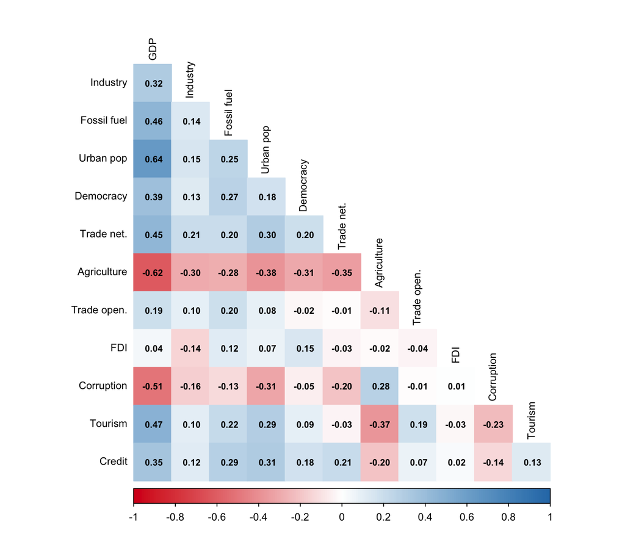

Figure 1: Correlation matrix of all 12 candidate regressors. Note that noise variables (last five rows/columns) are correlated with GDP and other true predictors.

```r
# Compute correlation matrix for all 12 candidate regressors
cor_matrix <- synth_data |>
  select(-country, -log_co2) |>                # exclude country names and DV
  cor()                                         # Pearson correlations

# Pretty variable names for the plot
colnames(cor_matrix) <- c("GDP", "Industry", "Fossil fuel", "Urban pop",
                          "Democracy", "Trade net.", "Agriculture",
                          "Trade open.", "FDI", "Corruption", "Tourism", "Credit")
rownames(cor_matrix) <- colnames(cor_matrix)

# Draw the heatmap
corrplot(cor_matrix,
         method = "color",                      # filled squares
         type = "lower",                        # lower triangle only
         addCoef.col = "black",                 # add correlation numbers
         number.cex = 0.7,                      # size of numbers
         tl.col = "black",                      # label color
         tl.cex = 0.8,                          # label size
         col = colorRampPalette(c("#d7191c", "white", "#2c7bb6"))(200),
         diag = FALSE,                          # hide the diagonal
         title = "",                            # title handled by fig-cap
         mar = c(0, 0, 0, 0))                  # margins
```

The correlation heatmap reveals the realistic structure we built into the data. GDP is positively correlated with fossil fuel use, urbanization, industry, and the trade network—but also with the noise variables like trade openness, tourism, and credit. This multicollinearity is precisely what makes a naive “throw everything into OLS” approach unreliable.

**NoteWhat we learned**

We created a synthetic dataset where we *know* which 7 variables truly affect CO<sub>2</sub> emissions and which 5 are noise. The noise variables are deliberately correlated with the true predictors, mimicking the multicollinearity found in real cross-country data.

# 3 The General Model

## 3.1 The Regression Equation

Our goal is to estimate the following linear model:

$$\log(\text{CO}_{2,i}) = \beta_0 + \sum_{j=1}^{12} \beta_j x_{j,i} + \varepsilon_i
\tag{1}$$

where:

- $\log(\text{CO}_{2,i})$ is the log of CO<sub>2</sub> emissions for country $i$
- $\beta_0$ is the **intercept** (the predicted log CO<sub>2</sub> when all regressors are zero)
- $\beta_j$ is the **coefficient** on the $j$-th regressor: the change in log CO<sub>2</sub> associated with a one-unit increase in $x_j$, holding all other variables constant
- $\varepsilon_i$ is the **error term**: everything that affects CO<sub>2</sub> emissions but is not captured by the 12 regressors. We assume $\varepsilon_i \sim N(0, \sigma^2)$.

## 3.2 Interpreting the Coefficients

Because the dependent variable is in logs, the interpretation of each coefficient depends on whether the regressor is also in logs:

| Regressor type | Interpretation of $\beta_j$ | Example |
| --- | --- | --- |
| Log-log (e.g., log GDP) | **Elasticity**: a 1% increase in GDP is associated with a $\beta_j$% change in CO<sub>2</sub> | $\beta = 1.2$ means 1% more GDP $\to$ 1.2% more CO<sub>2</sub> |
| Level-log (e.g., fossil fuel %) | **Semi-elasticity**: a 1-unit increase in the regressor is associated with a $100 \times \beta_j$% change in CO<sub>2</sub> | $\beta = 0.012$ means 1 pp more fossil fuel $\to$ 1.2% more CO<sub>2</sub> |

## 3.3 Our Goal

We want to determine **which $\beta_j$ are truly nonzero**. We know the answer (we designed the data), but let us first see what happens if we just run OLS with all 12 variables.

**OLS regression with all 12 candidate variables**

```r
# Run OLS with all 12 candidate regressors
ols_full <- lm(log_co2 ~ log_gdp + industry + fossil_fuel + urban_pop +
                 democracy + trade_network + agriculture +
                 log_trade + fdi + corruption + log_tourism + log_credit,
               data = synth_data)

# Extract tidy summary
ols_summary <- broom::tidy(ols_full) |>
  filter(term != "(Intercept)") |>            # remove intercept for display
  mutate(
    true_beta = c(1.200, 0.008, 0.012, 0.010, 0.004, 0.500, 0.005,
                  0, 0, 0, 0, 0),             # known true coefficients
    is_noise  = c(rep(FALSE, 7), rep(TRUE, 5)), # noise flag
    significant = p.value < 0.05              # conventional significance
  )

# Display as a gt table
ols_summary |>
  select(term, estimate, std.error, statistic, p.value, true_beta, significant) |>
  gt() |>
  tab_header(
    title = "OLS with All 12 Variables",
    subtitle = "Some noise variables may appear significant due to multicollinearity"
  ) |>
  cols_label(
    term       = "Variable",
    estimate   = "OLS Estimate",
    std.error  = "Std. Error",
    statistic  = "t-statistic",
    p.value    = "p-value",
    true_beta  = md("True *β*"),
    significant = "Sig. at 5%?"
  ) |>
  fmt_number(columns = c(estimate, std.error, statistic), decimals = 4) |>
  fmt_number(columns = p.value, decimals = 4) |>
  fmt_number(columns = true_beta, decimals = 3) |>
  tab_style(
    style = cell_fill(color = "#ffebee"),
    locations = cells_body(rows = c(8:12))     # noise variables highlighted
  ) |>
  tab_footnote("Red rows are noise variables (true coefficient = 0).") |>
  tab_source_note("OLS estimated on n = 120 synthetic observations.")
```

OLS with All 12 Variables

Some noise variables may appear significant due to multicollinearity

| Variable | OLS Estimate | Std. Error | t-statistic | p-value | True *β* | Sig. at 5%? |
| --- | --- | --- | --- | --- | --- | --- |
| log_gdp | 1.2276 | 0.0353 | 34.8243 | 0.0000 | 1.200 | TRUE |
| industry | 0.0097 | 0.0046 | 2.1119 | 0.0370 | 0.008 | TRUE |
| fossil_fuel | 0.0159 | 0.0027 | 5.8076 | 0.0000 | 0.012 | TRUE |
| urban_pop | 0.0091 | 0.0023 | 4.0533 | 0.0001 | 0.010 | TRUE |
| democracy | 0.0019 | 0.0034 | 0.5641 | 0.5738 | 0.004 | FALSE |
| trade_network | 0.1101 | 0.1948 | 0.5650 | 0.5733 | 0.500 | FALSE |
| agriculture | 0.0099 | 0.0039 | 2.5600 | 0.0119 | 0.005 | TRUE |
| log_trade | −0.0888 | 0.0506 | −1.7550 | 0.0821 | 0.000 | FALSE |
| fdi | −0.0233 | 0.0068 | −3.4079 | 0.0009 | 0.000 | TRUE |
| corruption | −0.0718 | 0.1771 | −0.4052 | 0.6861 | 0.000 | FALSE |
| log_tourism | −0.0117 | 0.0249 | −0.4711 | 0.6385 | 0.000 | FALSE |
| log_credit | 0.0293 | 0.0448 | 0.6536 | 0.5148 | 0.000 | FALSE |

Red rows are noise variables (true coefficient = 0).  
OLS estimated on n = 120 synthetic observations.

Look carefully at the noise variables (highlighted in red). Some may have p-values below 0.05—appearing “significant”—even though their true effect is exactly zero. This is **spurious significance**, caused by the correlation between noise variables and the true predictors. It is precisely this problem that motivates the three methods we study next.

**WarningThe danger of naive OLS**

With 12 correlated regressors and only 120 observations, OLS can produce misleading significance levels. A variable with a true coefficient of zero may appear significant simply because it is correlated with a genuinely important predictor. This is why we need principled variable selection methods.

# PART 1: Bayesian Model Averaging

# 4 Bayes’ Rule — The Foundation

Before we can understand Bayesian Model Averaging, we need to understand **Bayes’ rule**—the mathematical machinery that powers the entire framework. Do not worry if you have never seen Bayesian statistics before; we will build from scratch.

## 4.1 A Coin-Flip Example

Suppose a friend gives you a coin. You want to know: **is this coin fair** (probability of heads = 0.5), or is it **biased** (probability of heads = 0.7)?

Before flipping, you have no strong opinion. You assign equal **prior probabilities**:

- $P(\text{fair}) = 0.5$ (50% chance the coin is fair)
- $P(\text{biased}) = 0.5$ (50% chance the coin is biased)

Now you flip the coin 10 times and observe **7 heads**. How should you update your beliefs?

The **likelihood** of seeing 7 heads in 10 flips is:

- If the coin is fair ($p = 0.5$): $P(\text{7 heads} | \text{fair}) = \binom{10}{7} (0.5)^{10} = 0.1172$
- If the coin is biased ($p = 0.7$): $P(\text{7 heads} | \text{biased}) = \binom{10}{7} (0.7)^7 (0.3)^3 = 0.2668$

The biased coin makes the data more likely. Bayes’ rule combines the prior and the likelihood:

$$P(H|D) = \frac{P(D|H) \cdot P(H)}{P(D)}
\tag{2}$$

where:

- $P(H|D)$ = **posterior probability** (what we believe *after* seeing the data)
- $P(D|H)$ = **likelihood** (how probable the data is under hypothesis $H$)
- $P(H)$ = **prior probability** (what we believed *before* seeing the data)
- $P(D)$ = **marginal likelihood** (a normalizing constant that ensures probabilities sum to 1)

For our coin:

$$P(\text{fair}|\text{7H}) = \frac{0.1172 \times 0.5}{0.1172 \times 0.5 + 0.2668 \times 0.5} = \frac{0.0586}{0.1920} = 0.305$$

$$P(\text{biased}|\text{7H}) = \frac{0.2668 \times 0.5}{0.1920} = 0.695$$

After seeing 7 heads, we update from 50-50 to roughly 30-70 in favor of the biased coin. **The data shifted our beliefs, but did not erase the prior entirely.**

## 4.2 The Bridge to Model Averaging

Now replace “fair coin” and “biased coin” with *regression models*:

- Hypothesis = “Which variables belong in the model?”
- Prior = “Before seeing data, any combination of variables is equally plausible”
- Likelihood = “How well does each model fit the data?”
- Posterior = “After seeing data, which models are most credible?”

This is exactly what BMA does. Instead of two coin hypotheses, we have 4,096 model hypotheses—but the logic of Bayes’ rule is identical.

**NoteWhat we learned**

Bayes’ rule updates prior beliefs using data. The posterior probability of any hypothesis is proportional to its prior probability times its likelihood. BMA applies this same logic to regression models instead of coin flips.

# 5 The BMA Framework

## 5.1 Posterior Model Probability

With 12 candidate variables, there are $K = 12$ regressors and $2^K = 4{,}096$ possible models. Denote the $k$-th model as $M_k$. BMA assigns each model a **posterior probability**:

$$P(M_k | y) = \frac{P(y | M_k) \cdot P(M_k)}{\sum_{l=1}^{2^K} P(y | M_l) \cdot P(M_l)}
\tag{3}$$

This is just Bayes’ rule applied to models. Let us unpack each piece:

- **$P(y | M_k)$** is the **marginal likelihood** of model $M_k$. It measures how well the model fits the data, *automatically penalizing complexity*. A model with many parameters can fit the data closely, but the marginal likelihood integrates over all possible parameter values, spreading the probability thin. This acts as a built-in **Occam’s razor**: simpler models that fit the data well receive higher marginal likelihoods than complex models that fit only slightly better.
- **$P(M_k)$** is the **prior model probability**. With no prior information, we use a **uniform prior**: every model is equally likely, so $P(M_k) = 1/4{,}096$ for all $k$. This means the posterior is driven entirely by the data.
- The **denominator** is a normalizing constant that ensures all posterior model probabilities sum to 1.

## 5.2 Posterior Inclusion Probability (PIP)

We do not really care about individual models—we care about individual *variables*. The **Posterior Inclusion Probability** of variable $j$ is the sum of the posterior probabilities of all models that include variable $j$:

$$\text{PIP}_j = \sum_{k:\, j \in M_k} P(M_k | y)
\tag{4}$$

Think of it as a **democratic vote**. Each of the 4,096 models casts a vote for which variables matter. But the votes are *weighted*: models that fit the data well get louder voices. If variable $j$ appears in most of the high-probability models, it earns a high PIP.

The standard interpretation thresholds (Raftery, 1995):

| PIP range | Interpretation | Analogy |
| --- | --- | --- |
| $\geq 0.99$ | Decisive evidence | Beyond reasonable doubt |
| $0.95 - 0.99$ | Very strong evidence | Strong consensus |
| $0.80 - 0.95$ | Strong evidence (robust) | Clear majority |
| $0.50 - 0.80$ | Borderline evidence | Split vote |
| $< 0.50$ | Weak/no evidence (fragile) | Minority opinion |

We will use **PIP $\geq$ 0.80** as our threshold for “robust” throughout this tutorial.

## 5.3 Posterior Mean

Once we know which variables matter, we want to know *how much* they matter. The **posterior mean** of coefficient $j$ is:

$$E[\beta_j | y] = \sum_{k=1}^{2^K} \hat{\beta}_{j,k} \cdot P(M_k | y)
\tag{5}$$

where $\hat{\beta}_{j,k}$ is the estimated coefficient of variable $j$ in model $k$ (and zero if $j$ is not in model $k$). This is a weighted average of the coefficient across all models. Variables with high PIPs get posterior means close to their “full model” estimates; variables with low PIPs get posterior means shrunk toward zero.

**NoteWhat we learned**

BMA assigns posterior probabilities to all $2^K$ models using Bayes’ rule. The Posterior Inclusion Probability (PIP) aggregates these model probabilities into a single measure of variable importance. PIP $\geq$ 0.80 indicates a robust determinant.

# 6 Toy Example — BMA on 4 Variables

Before running BMA on all 12 variables, let us work through a small example by hand. We pick 4 variables from our dataset: **log_gdp** and **fossil_fuel** (true predictors) and **fdi** and **corruption** (noise). With 4 variables, there are $2^4 = 16$ possible models.

**Enumerate all 16 models with 4 variables and compute BIC-based posterior probabilities**

```r
# Select the 4 variables for the toy example
toy_data <- synth_data |>
  select(log_co2, log_gdp, fossil_fuel, fdi, corruption)

# Define the 4 variable names
toy_vars <- c("log_gdp", "fossil_fuel", "fdi", "corruption")

# Enumerate all 2^4 = 16 possible subsets
# Each model is a binary vector of length 4 (include/exclude each variable)
all_models <- expand.grid(
  log_gdp     = c(0, 1),                      # 0 = exclude, 1 = include
  fossil_fuel = c(0, 1),
  fdi         = c(0, 1),
  corruption  = c(0, 1)
)

# Fit each model and compute BIC
model_results <- all_models |>
  mutate(model_id = row_number()) |>           # label each model
  rowwise() |>
  mutate(
    # Build the formula from included variables
    included_vars = list(toy_vars[c(log_gdp, fossil_fuel, fdi, corruption) == 1]),
    n_vars = length(included_vars),
    formula_str = if (n_vars == 0) {
      "log_co2 ~ 1"                            # intercept-only model
    } else {
      paste("log_co2 ~", paste(included_vars, collapse = " + "))
    },
    # Fit OLS and extract BIC
    fit = list(lm(as.formula(formula_str), data = toy_data)),
    bic = BIC(fit),
    r_squared = summary(fit)$r.squared
  ) |>
  ungroup()

# Convert BIC to approximate posterior probabilities
# P(M_k|y) ∝ exp(-0.5 * BIC_k) under uniform priors
model_results <- model_results |>
  mutate(
    log_weight = -0.5 * (bic - min(bic)),      # subtract min BIC for numerical stability
    weight     = exp(log_weight),               # convert to raw weights
    post_prob  = weight / sum(weight)           # normalize to probabilities
  )

# Display the top 8 models by posterior probability
model_results |>
  arrange(desc(post_prob)) |>
  head(8) |>
  select(model_id, log_gdp, fossil_fuel, fdi, corruption, bic, post_prob) |>
  gt() |>
  tab_header(
    title = "Top 8 Models (of 16) by Posterior Probability",
    subtitle = "BIC-based approximation with uniform model prior"
  ) |>
  cols_label(
    model_id    = "Model",
    log_gdp     = "GDP?",
    fossil_fuel = "Fossil?",
    fdi         = "FDI?",
    corruption  = "Corrupt?",
    bic         = "BIC",
    post_prob   = "P(M|y)"
  ) |>
  fmt_number(columns = bic, decimals = 1) |>
  fmt_number(columns = post_prob, decimals = 4) |>
  tab_footnote("1 = included, 0 = excluded. Posterior probabilities from BIC approximation.")
```

Top 8 Models (of 16) by Posterior Probability

BIC-based approximation with uniform model prior

| Model | GDP? | Fossil? | FDI? | Corrupt? | BIC | P(M\|y) |
| --- | --- | --- | --- | --- | --- | --- |
| 8 | 1 | 1 | 1 | 0 | 85.1 | 0.8298 |
| 16 | 1 | 1 | 1 | 1 | 89.6 | 0.0846 |
| 4 | 1 | 1 | 0 | 0 | 89.8 | 0.0774 |
| 12 | 1 | 1 | 0 | 1 | 94.3 | 0.0081 |
| 6 | 1 | 0 | 1 | 0 | 104.6 | 0.0000 |
| 2 | 1 | 0 | 0 | 0 | 105.2 | 0.0000 |
| 14 | 1 | 0 | 1 | 1 | 109.3 | 0.0000 |
| 10 | 1 | 0 | 0 | 1 | 109.9 | 0.0000 |

1 = included, 0 = excluded. Posterior probabilities from BIC approximation.

Now let us compute the PIPs by summing the posterior probabilities of all models that include each variable:

**Compute and plot PIPs for the 4-variable toy example**

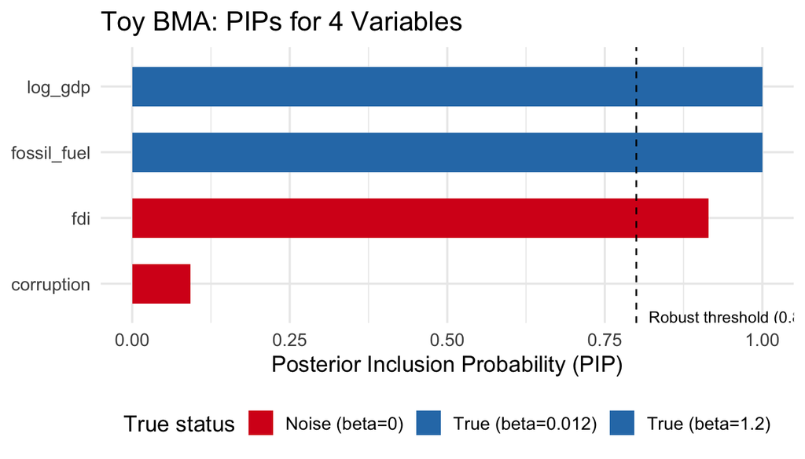

```r
# Compute PIPs by hand: sum P(M_k|y) for all models containing each variable
pip_toy <- tibble(
  variable = toy_vars,
  pip = c(
    sum(model_results$post_prob[model_results$log_gdp == 1]),      # PIP for GDP
    sum(model_results$post_prob[model_results$fossil_fuel == 1]),   # PIP for fossil_fuel
    sum(model_results$post_prob[model_results$fdi == 1]),           # PIP for fdi
    sum(model_results$post_prob[model_results$corruption == 1])     # PIP for corruption
  ),
  true_effect = c("True (beta=1.2)", "True (beta=0.012)", "Noise (beta=0)", "Noise (beta=0)")
)

# Bar chart of PIPs
ggplot(pip_toy, aes(x = reorder(variable, pip), y = pip, fill = true_effect)) +
  geom_col(width = 0.6) +                     # horizontal bars
  geom_hline(yintercept = 0.80,               # robust threshold
             linetype = "dashed", color = "black", linewidth = 0.5) +
  annotate("text", x = 0.5, y = 0.82, label = "Robust threshold (0.80)",
           hjust = 0, size = 3.5) +
  coord_flip() +                               # flip to horizontal
  scale_fill_manual(values = c("True (beta=1.2)" = "#2c7bb6",
                                "True (beta=0.012)" = "#2c7bb6",
                                "Noise (beta=0)" = "#d7191c")) +
  scale_y_continuous(limits = c(0, 1), labels = label_number(accuracy = 0.01)) +
  labs(x = NULL, y = "Posterior Inclusion Probability (PIP)",
       fill = "True status",
       title = "Toy BMA: PIPs for 4 Variables") +
  theme_minimal(base_size = 14) +
  theme(legend.position = "bottom")
```

# 7 BMA on All 12 Variables

Now we apply BMA to the full dataset with all 12 candidate regressors using the `BMS` package.

## 7.1 Running BMA

**Run BMA with the BMS package on all 12 variables**

```r
set.seed(2021)  # reproducibility for MCMC sampling

# Prepare the data matrix: DV in first column, regressors follow
bma_data <- synth_data |>
  select(log_co2, log_gdp, industry, fossil_fuel, urban_pop,
         democracy, trade_network, agriculture,
         log_trade, fdi, corruption, log_tourism, log_credit) |>
  as.data.frame()                              # BMS requires a data.frame

# Run BMA with:
# - burn = 50000: discard first 50,000 MCMC draws (burn-in period)
# - iter = 200000: keep 200,000 draws for inference
# - g = "BRIC": benchmark risk inflation criterion g-prior
# - mprior = "uniform": every model equally likely a priori
bma_fit <- bms(
  X.data     = bma_data,                       # data with DV in column 1
  burn       = 50000,                          # burn-in iterations
  iter       = 200000,                         # post-burn-in iterations
  g          = "BRIC",                         # BRIC g-prior (robust default)
  mprior     = "uniform",                      # uniform model prior
  nmodel     = 2000,                           # store top 2000 models
  mcmc       = "bd",                           # birth-death MCMC sampler
  user.int   = FALSE                           # suppress interactive output
)
```

**PIP bar chart from BMA results**

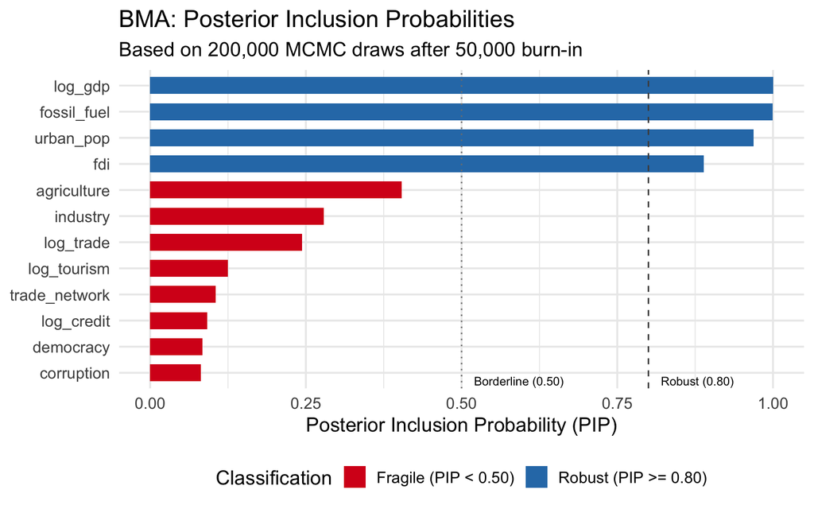

```r
# Define a lookup table for the known true coefficients
true_beta_lookup <- c(
  log_gdp = 1.200, industry = 0.008, fossil_fuel = 0.012,
  urban_pop = 0.010, democracy = 0.004, trade_network = 0.500,
  agriculture = 0.005, log_trade = 0, fdi = 0, corruption = 0,
  log_tourism = 0, log_credit = 0
)

# Extract PIPs and posterior means from BMA
bma_coefs <- coef(bma_fit)                     # matrix with PIP, post mean, post SD, etc.
bma_df <- as.data.frame(bma_coefs) |>
  rownames_to_column("variable") |>
  as_tibble() |>
  rename(pip = PIP, post_mean = `Post Mean`, post_sd = `Post SD`) |>
  select(variable, pip, post_mean, post_sd) |> # keep only the columns we need
  mutate(
    true_beta = true_beta_lookup[variable],    # match true betas by variable name
    robustness = case_when(
      pip >= 0.80 ~ "Robust (PIP >= 0.80)",
      pip >= 0.50 ~ "Borderline",
      TRUE        ~ "Fragile (PIP < 0.50)"
    )
  )

# PIP bar chart
ggplot(bma_df, aes(x = reorder(variable, pip), y = pip, fill = robustness)) +
  geom_col(width = 0.65) +                    # draw bars
  geom_hline(yintercept = 0.80,               # robust threshold line
             linetype = "dashed", color = "gray30", linewidth = 0.5) +
  geom_hline(yintercept = 0.50,               # borderline threshold
             linetype = "dotted", color = "gray50", linewidth = 0.5) +
  annotate("text", x = 0.7, y = 0.82, label = "Robust (0.80)", hjust = 0, size = 3) +
  annotate("text", x = 0.7, y = 0.52, label = "Borderline (0.50)", hjust = 0, size = 3) +
  coord_flip() +                               # horizontal bars
  scale_fill_manual(values = c("Robust (PIP >= 0.80)" = "#2c7bb6",
                                "Borderline" = "#fdae61",
                                "Fragile (PIP < 0.50)" = "#d7191c")) +
  scale_y_continuous(limits = c(0, 1), labels = label_number(accuracy = 0.01)) +
  labs(x = NULL, y = "Posterior Inclusion Probability (PIP)",
       fill = "Classification",
       title = "BMA: Posterior Inclusion Probabilities",
       subtitle = "Based on 200,000 MCMC draws after 50,000 burn-in") +
  theme_minimal(base_size = 14) +
  theme(legend.position = "bottom")
```

**Posterior coefficient estimates with credible intervals**

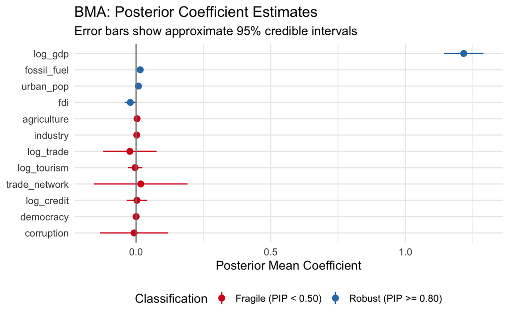

Figure 4: BMA posterior mean coefficients with approximate 95% credible intervals. Variables ordered by PIP.

```r
# Compute approximate 95% credible intervals (posterior mean +/- 2 * posterior SD)
bma_df <- bma_df |>
  mutate(
    ci_low  = post_mean - 2 * post_sd,        # lower bound of ~95% interval
    ci_high = post_mean + 2 * post_sd          # upper bound of ~95% interval
  )

# Coefficient plot with credible intervals
ggplot(bma_df, aes(x = reorder(variable, pip), y = post_mean, color = robustness)) +
  geom_pointrange(aes(ymin = ci_low, ymax = ci_high), size = 0.5) +
  geom_hline(yintercept = 0, linetype = "solid", color = "gray50") +
  coord_flip() +
  scale_color_manual(values = c("Robust (PIP >= 0.80)" = "#2c7bb6",
                                 "Borderline" = "#fdae61",
                                 "Fragile (PIP < 0.50)" = "#d7191c")) +
  labs(x = NULL, y = "Posterior Mean Coefficient",
       color = "Classification",
       title = "BMA: Posterior Coefficient Estimates",
       subtitle = "Error bars show approximate 95% credible intervals") +
  theme_minimal(base_size = 14) +
  theme(legend.position = "bottom")
```

**Model inclusion matrix showing top 50 models**

[figure not shown]

Figure 5: Model inclusion matrix: each column is a model (sorted by posterior probability), each row is a variable. Blue = included, white = excluded. The most probable models consistently include the true predictors.

```r
# Extract the top 50 best models and their variable inclusion patterns
top_models <- topmodels.bma(bma_fit)[, 1:min(50, ncol(topmodels.bma(bma_fit)))]

# Convert to a long data frame for ggplot
inclusion_df <- as.data.frame(top_models != 0) |>  # TRUE = included

  rownames_to_column("variable") |>
  pivot_longer(-variable, names_to = "model", values_to = "included") |>
  mutate(
    model_num = as.integer(gsub(".*\\.", "", model)),
    included  = as.numeric(included)
  )

# Order variables by PIP (highest at top)
var_order <- bma_df |> arrange(pip) |> pull(variable)
inclusion_df$variable <- factor(inclusion_df$variable, levels = var_order)

# Create heatmap
ggplot(inclusion_df, aes(x = factor(model_num), y = variable, fill = factor(included))) +
  geom_tile(color = "white", linewidth = 0.2) +
  scale_fill_manual(values = c("0" = "gray95", "1" = "#2c7bb6"),
                    labels = c("Excluded", "Included")) +
  labs(x = "Model rank (left = highest posterior probability)",
       y = NULL, fill = NULL,
       title = "Model Inclusion Matrix (Top 50 Models)") +
  theme_minimal(base_size = 12) +
  theme(axis.text.x = element_blank(),         # too many model labels
        axis.ticks.x = element_blank(),
        legend.position = "bottom",
        panel.grid = element_blank())
```

## 7.5 Interpreting the BMA Results

**Summary table of BMA results vs. known truth**

```r
# Create a summary table comparing BMA results with the true DGP
bma_summary <- bma_df |>
  arrange(desc(pip)) |>
  mutate(
    bma_robust = pip >= 0.80,                  # BMA says robust?
    true_nonzero = true_beta != 0,             # truly nonzero?
    correct = bma_robust == true_nonzero       # correct classification?
  ) |>
  select(variable, true_beta, pip, post_mean, bma_robust, true_nonzero, correct)

bma_summary |>
  gt() |>
  tab_header(
    title = "BMA Results vs. Known Truth",
    subtitle = "Did BMA correctly identify the true predictors?"
  ) |>
  cols_label(
    variable     = "Variable",
    true_beta    = md("True *β*"),
    pip          = "PIP",
    post_mean    = "Post. Mean",
    bma_robust   = "BMA Robust?",
    true_nonzero = "Truly Nonzero?",
    correct      = "Correct?"
  ) |>
  fmt_number(columns = c(true_beta, pip, post_mean), decimals = 4) |>
  tab_style(
    style = cell_fill(color = "#e8f5e9"),
    locations = cells_body(rows = correct == TRUE)
  ) |>
  tab_style(
    style = cell_fill(color = "#ffebee"),
    locations = cells_body(rows = correct == FALSE)
  ) |>
  tab_footnote("Green = correct classification; red = misclassification. Robust threshold: PIP >= 0.80.")
```

Table 2

BMA Results vs. Known Truth

Did BMA correctly identify the true predictors?

| Variable | True *β* | PIP | Post. Mean | BMA Robust? | Truly Nonzero? | Correct? |
| --- | --- | --- | --- | --- | --- | --- |
| log_gdp | 1.2000 | 1.0000 | 1.2165 | TRUE | TRUE | TRUE |
| fossil_fuel | 0.0120 | 0.9995 | 0.0154 | TRUE | TRUE | TRUE |
| urban_pop | 0.0100 | 0.9685 | 0.0088 | TRUE | TRUE | TRUE |
| fdi | 0.0000 | 0.8888 | −0.0213 | TRUE | FALSE | FALSE |
| agriculture | 0.0050 | 0.4043 | 0.0036 | FALSE | TRUE | FALSE |
| industry | 0.0080 | 0.2789 | 0.0026 | FALSE | TRUE | FALSE |
| log_trade | 0.0000 | 0.2440 | −0.0230 | FALSE | FALSE | TRUE |
| log_tourism | 0.0000 | 0.1246 | −0.0035 | FALSE | FALSE | TRUE |
| trade_network | 0.5000 | 0.1051 | 0.0174 | FALSE | TRUE | FALSE |
| log_credit | 0.0000 | 0.0917 | 0.0033 | FALSE | FALSE | TRUE |
| democracy | 0.0040 | 0.0840 | 0.0002 | FALSE | TRUE | FALSE |
| corruption | 0.0000 | 0.0818 | −0.0072 | FALSE | FALSE | TRUE |

Green = correct classification; red = misclassification. Robust threshold: PIP >= 0.80.

# PART 2: LASSO

# 8 Regularization — Adding a Penalty

## 8.1 The Bias-Variance Tradeoff

OLS is an **unbiased** estimator—on average, it gets the coefficients right. But with many correlated regressors, OLS coefficients have **high variance**: they bounce around from sample to sample. Adding or removing a single variable can drastically change the estimates.

The key insight of regularization is that a **little bias can buy a lot of variance reduction**, lowering the overall prediction error. Think of it as a tradeoff:

|  | Low bias | High bias |
| --- | --- | --- |
| **Low variance** | Ideal (but rare) | Regularized (LASSO, Ridge) |
| **High variance** | OLS with many regressors | Terrible |

The **total error** of a prediction decomposes as:

$$\text{MSE} = \text{Bias}^2 + \text{Variance} + \text{Irreducible noise}
\tag{6}$$

**Bias-variance tradeoff illustration**

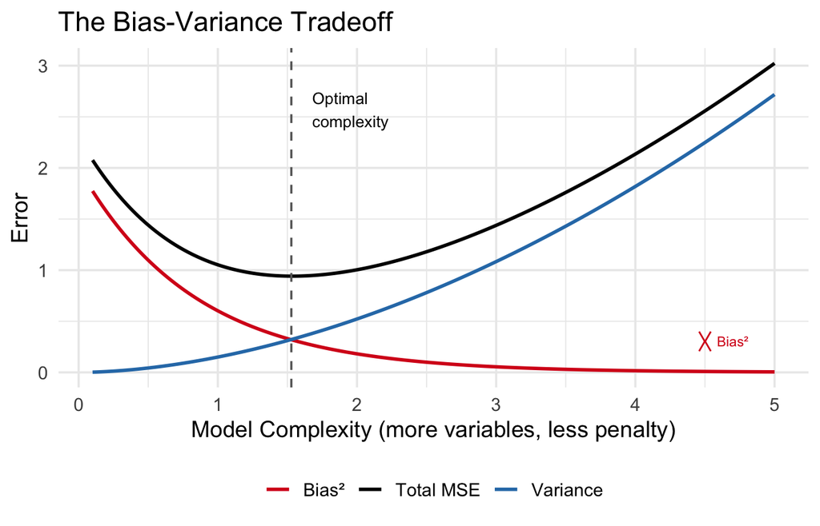

Figure 6: The bias-variance tradeoff. As model complexity increases (more variables, less regularization), bias decreases but variance increases. The optimal point is a compromise.

```r
# Create an illustrative bias-variance tradeoff curve
complexity <- seq(0.1, 5, length.out = 200)    # model complexity axis

# Define curves (for illustration, not real data)
bias_sq  <- 2 * exp(-1.2 * complexity)          # bias decreases with complexity
variance <- 0.15 * complexity^1.8               # variance increases with complexity
total    <- bias_sq + variance + 0.3            # total MSE = bias^2 + variance + noise

# Store length before creating tibble (tibble evaluates columns left-to-right)
n_pts <- length(complexity)

bv_data <- tibble(
  complexity = rep(complexity, 3),
  value = c(bias_sq, variance, total),
  component = rep(c("Bias\u00b2", "Variance", "Total MSE"), each = n_pts)
)

# Find the minimum of total MSE
opt_idx <- which.min(total)
opt_x   <- complexity[opt_idx]
opt_y   <- total[opt_idx]

ggplot(bv_data, aes(x = complexity, y = value, color = component, linetype = component)) +
  geom_line(linewidth = 1) +                   # draw the three curves
  geom_vline(xintercept = opt_x, linetype = "dashed", color = "gray40") +
  annotate("text", x = opt_x + 0.15, y = max(total) * 0.85,
           label = "Optimal\ncomplexity", hjust = 0, size = 3.5) +
  annotate("segment", x = 4.5, xend = 4.5, y = 0.3, yend = 0.3 + bias_sq[190],
           color = "#d7191c", linewidth = 0.5,
           arrow = arrow(ends = "both", length = unit(0.1, "inches"))) +
  annotate("text", x = 4.7, y = 0.3 + bias_sq[190]/2, label = "Bias\u00b2",
           color = "#d7191c", size = 3) +
  scale_color_manual(values = c("Bias\u00b2" = "#d7191c", "Variance" = "#2c7bb6",
                                 "Total MSE" = "black")) +
  scale_linetype_manual(values = c("Bias\u00b2" = "solid", "Variance" = "solid",
                                    "Total MSE" = "solid")) +
  labs(x = "Model Complexity (more variables, less penalty)",
       y = "Error", color = NULL, linetype = NULL,
       title = "The Bias-Variance Tradeoff") +
  theme_minimal(base_size = 14) +
  theme(legend.position = "bottom")
```

**The penalty as a “budget constraint.”** Imagine you are shopping for regression coefficients, but you have a limited budget. The regularization penalty says: “You can have large coefficients, but you must pay for them. The more you spend on one coefficient, the less you have left for others.” Variables that do not contribute enough to prediction are not worth the cost, so their coefficients are set to zero.

**NoteWhat we learned**

Regularization deliberately introduces a small bias to reduce variance, often lowering overall prediction error. The penalty acts as a budget constraint on coefficient sizes.

# 9 L1 vs. L2 Geometry

## 9.1 The LASSO (L1) Penalty

The LASSO solves the following optimization problem:

$$\hat{\beta}_{\text{LASSO}} = \arg\min_\beta \; \frac{1}{2n}\|y - X\beta\|^2 + \lambda \|\beta\|_1
\tag{7}$$

where:

- $\frac{1}{2n}\|y - X\beta\|^2$ is the **sum of squared residuals** (the usual OLS loss, scaled)
- $\|\beta\|_1 = \sum_{j=1}^{p} |\beta_j|$ is the **L1 norm** (sum of absolute values)
- $\lambda \geq 0$ is the **regularization parameter**: it controls how much we penalize large coefficients. When $\lambda = 0$, LASSO reduces to OLS. As $\lambda \to \infty$, all coefficients are shrunk to zero.

## 9.2 The Ridge (L2) Penalty

For comparison, **Ridge regression** uses the L2 norm instead:

$$\hat{\beta}_{\text{Ridge}} = \arg\min_\beta \; \frac{1}{2n}\|y - X\beta\|^2 + \lambda \|\beta\|_2^2
\tag{8}$$

where $\|\beta\|_2^2 = \sum_{j=1}^{p} \beta_j^2$ is the sum of squared coefficients.

## 9.3 Why LASSO Selects Variables and Ridge Does Not

The geometric explanation is one of the most elegant ideas in modern statistics. The constraint region for LASSO (L1) is a **diamond**, while the constraint region for Ridge (L2) is a **circle**. When the elliptical OLS contours meet the diamond, they typically hit a **corner**, where one or more coefficients are exactly zero. When they meet the circle, they hit a smooth curve—coefficients are shrunk but never exactly zero.

**L1 (LASSO) constraint geometry**

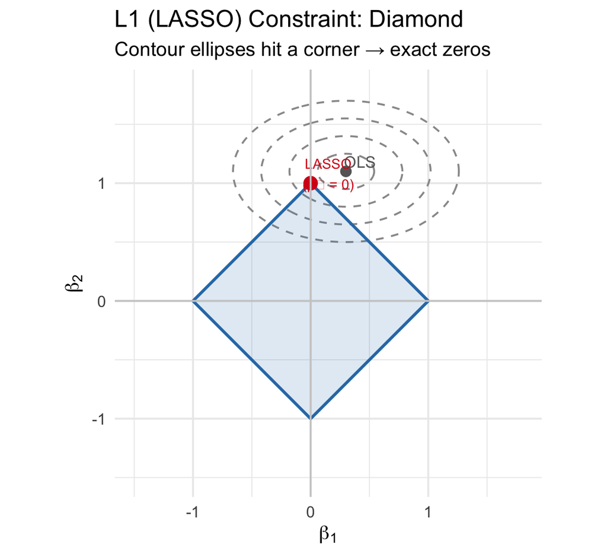

Figure 7: LASSO geometry: the L1 constraint region is a diamond. The OLS contour ellipses typically hit a corner, setting one coefficient to exactly zero.

```r
# Create the L1 diamond constraint region
t_val <- 1.0                                   # constraint budget
theta <- seq(0, 2 * pi, length.out = 400)      # angles for parametric curve

# L1 diamond: |beta1| + |beta2| <= t
diamond <- tibble(
  b1 = t_val * c(cos(theta) * (abs(cos(theta)) + abs(sin(theta)))^(-1)),
  b2 = t_val * c(sin(theta) * (abs(cos(theta)) + abs(sin(theta)))^(-1))
)

# Manual diamond vertices for clean shape
diamond_clean <- tibble(
  b1 = c(t_val, 0, -t_val, 0, t_val),
  b2 = c(0, t_val, 0, -t_val, 0)
)

# OLS solution (illustrative point outside the diamond)
ols_b1 <- 0.3
ols_b2 <- 1.1

# Elliptical contours centered on OLS
contour_data <- map_dfr(c(0.3, 0.6, 0.9, 1.2), function(r) {
  tibble(
    b1 = ols_b1 + r * 0.8 * cos(theta),       # wider in b1 direction
    b2 = ols_b2 + r * 0.5 * sin(theta),        # narrower in b2
    level = r
  )
})

ggplot() +
  # Draw OLS contour ellipses
  geom_path(data = contour_data, aes(x = b1, y = b2, group = level),
            color = "gray60", linetype = "dashed") +
  # Draw the L1 diamond
  geom_polygon(data = diamond_clean, aes(x = b1, y = b2),
               fill = "#2c7bb6", alpha = 0.15, color = "#2c7bb6", linewidth = 1) +
  # Mark the OLS solution
  geom_point(aes(x = ols_b1, y = ols_b2), size = 3, color = "gray40") +
  annotate("text", x = ols_b1 + 0.12, y = ols_b2 + 0.08,
           label = "OLS", size = 4, color = "gray40") +
  # Mark the LASSO solution (at a corner: b1 = 0)
  geom_point(aes(x = 0, y = t_val), size = 4, color = "#d7191c") +
  annotate("text", x = 0.15, y = t_val + 0.08,
           label = "LASSO\n(β₁ = 0)", size = 3.5, color = "#d7191c") +
  # Axes
  geom_hline(yintercept = 0, color = "gray80") +
  geom_vline(xintercept = 0, color = "gray80") +
  coord_equal(xlim = c(-1.5, 1.8), ylim = c(-1.5, 1.8)) +
  labs(x = expression(beta[1]), y = expression(beta[2]),
       title = "L1 (LASSO) Constraint: Diamond",
       subtitle = "Contour ellipses hit a corner → exact zeros") +
  theme_minimal(base_size = 14)
```

**L2 (Ridge) constraint geometry**

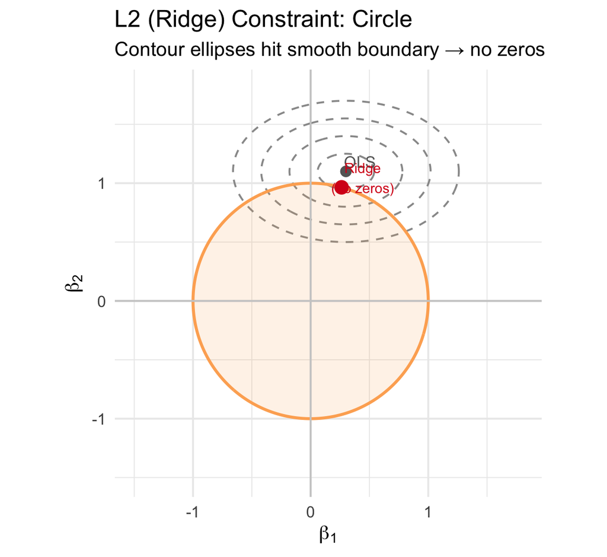

Figure 8: Ridge geometry: the L2 constraint region is a circle. The OLS contours hit the smooth boundary—coefficients are shrunk but never exactly zero.

```r
# L2 circle: beta1^2 + beta2^2 <= t^2
circle <- tibble(
  b1 = t_val * cos(theta),
  b2 = t_val * sin(theta)
)

# Ridge solution: closest point on circle to OLS
ols_norm   <- sqrt(ols_b1^2 + ols_b2^2)       # distance of OLS from origin
ridge_b1   <- ols_b1 * t_val / ols_norm        # project OLS onto circle boundary
ridge_b2   <- ols_b2 * t_val / ols_norm

ggplot() +
  # Draw OLS contour ellipses
  geom_path(data = contour_data, aes(x = b1, y = b2, group = level),
            color = "gray60", linetype = "dashed") +
  # Draw the L2 circle
  geom_polygon(data = circle, aes(x = b1, y = b2),
               fill = "#fdae61", alpha = 0.15, color = "#fdae61", linewidth = 1) +
  # Mark the OLS solution
  geom_point(aes(x = ols_b1, y = ols_b2), size = 3, color = "gray40") +
  annotate("text", x = ols_b1 + 0.12, y = ols_b2 + 0.08,
           label = "OLS", size = 4, color = "gray40") +
  # Mark the Ridge solution
  geom_point(aes(x = ridge_b1, y = ridge_b2), size = 4, color = "#d7191c") +
  annotate("text", x = ridge_b1 + 0.18, y = ridge_b2 + 0.08,
           label = "Ridge\n(no zeros)", size = 3.5, color = "#d7191c") +
  # Axes
  geom_hline(yintercept = 0, color = "gray80") +
  geom_vline(xintercept = 0, color = "gray80") +
  coord_equal(xlim = c(-1.5, 1.8), ylim = c(-1.5, 1.8)) +
  labs(x = expression(beta[1]), y = expression(beta[2]),
       title = "L2 (Ridge) Constraint: Circle",
       subtitle = "Contour ellipses hit smooth boundary → no zeros") +
  theme_minimal(base_size = 14)
```

The key insight: **the L1 diamond has corners where coefficients are exactly zero—this is why LASSO selects variables.** The L2 circle has no corners, so Ridge shrinks coefficients toward zero but never reaches it. LASSO performs *simultaneous estimation and variable selection*; Ridge only estimates.

**NoteWhat we learned**

LASSO uses an L1 penalty (sum of absolute values) that creates a diamond-shaped constraint region. The corners of this diamond force some coefficients to be exactly zero, performing automatic variable selection. Ridge uses an L2 penalty (sum of squares) that creates a circle, which shrinks but never zeros out coefficients.

# 10 LASSO on All 12 Variables

## 10.1 Running LASSO with Cross-Validation

The LASSO has one tuning parameter: $\lambda$, which controls the strength of the penalty. Too small and we include noise; too large and we exclude true predictors. We choose $\lambda$ using **10-fold cross-validation**: split the data into 10 folds, train on 9, predict the 10th, and repeat. The $\lambda$ that minimizes the average prediction error across folds is called **lambda.min**.

**Fit LASSO with cross-validation using glmnet**

```r
set.seed(2021)  # reproducibility for cross-validation folds

# Prepare the design matrix X and response vector y
X <- synth_data |>
  select(log_gdp, industry, fossil_fuel, urban_pop, democracy,
         trade_network, agriculture, log_trade, fdi, corruption,
         log_tourism, log_credit) |>
  as.matrix()                                  # glmnet requires a matrix

y <- synth_data$log_co2                        # response vector

# Run LASSO (alpha = 1) with 10-fold cross-validation
lasso_cv <- cv.glmnet(
  x      = X,                                 # predictor matrix
  y      = y,                                 # response vector
  alpha  = 1,                                 # alpha=1 is LASSO (alpha=0 is Ridge)
  nfolds = 10,                                # 10-fold cross-validation
  standardize = TRUE                          # standardize predictors internally
)
```

## 10.2 Figure: Regularization Path

**LASSO regularization path: coefficients vs log(lambda)**

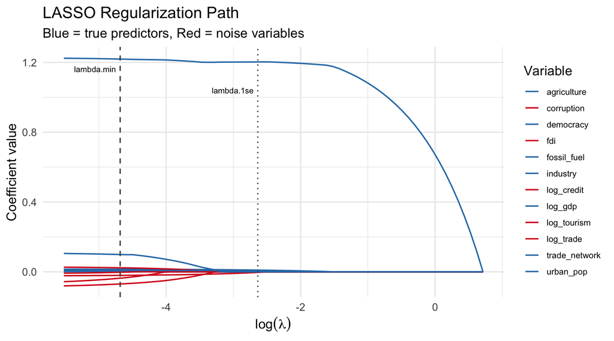

Figure 9: LASSO regularization path. Each colored line represents one variable’s coefficient as the penalty (lambda) increases from left to right. Variables with small effects are shrunk to zero first.

```r
# Fit the full LASSO path (not just CV)
lasso_full <- glmnet(X, y, alpha = 1, standardize = TRUE)

# Extract coefficient paths
coef_path <- as.matrix(coef(lasso_full))[-1, ]  # remove intercept row
lambda_vals <- lasso_full$lambda                  # lambda values

# Reshape to long format for ggplot
path_df <- as_tibble(t(coef_path)) |>
  mutate(log_lambda = log(lambda_vals)) |>
  pivot_longer(-log_lambda, names_to = "variable", values_to = "coefficient")

# Define colors: blue for true predictors, red for noise
var_colors <- c(
  log_gdp = "#2c7bb6", industry = "#2c7bb6", fossil_fuel = "#2c7bb6",
  urban_pop = "#2c7bb6", democracy = "#2c7bb6", trade_network = "#2c7bb6",
  agriculture = "#2c7bb6",
  log_trade = "#d7191c", fdi = "#d7191c", corruption = "#d7191c",
  log_tourism = "#d7191c", log_credit = "#d7191c"
)

ggplot(path_df, aes(x = log_lambda, y = coefficient, color = variable)) +
  geom_line(linewidth = 0.7) +                 # one line per variable
  geom_vline(xintercept = log(lasso_cv$lambda.min),    # lambda.min
             linetype = "dashed", color = "gray30") +
  geom_vline(xintercept = log(lasso_cv$lambda.1se),    # lambda.1se
             linetype = "dotted", color = "gray30") +
  annotate("text", x = log(lasso_cv$lambda.min), y = max(coef_path) * 0.95,
           label = "lambda.min", hjust = 1.1, size = 3) +
  annotate("text", x = log(lasso_cv$lambda.1se), y = max(coef_path) * 0.85,
           label = "lambda.1se", hjust = 1.1, size = 3) +
  scale_color_manual(values = var_colors) +
  labs(x = expression(log(lambda)),
       y = "Coefficient value",
       color = "Variable",
       title = "LASSO Regularization Path",
       subtitle = "Blue = true predictors, Red = noise variables") +
  theme_minimal(base_size = 14) +
  theme(legend.position = "right",
        legend.text = element_text(size = 9))
```

## 10.3 Figure: Cross-Validation Curve

**Cross-validation curve for LASSO**

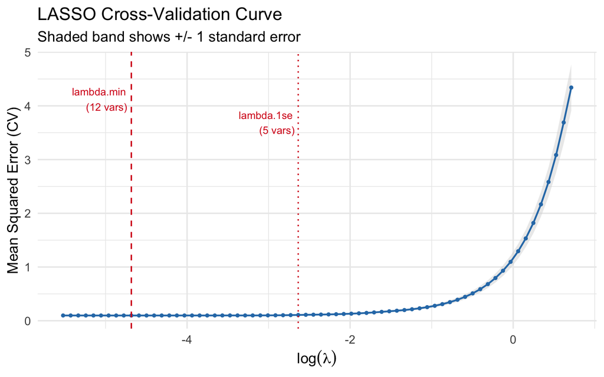

Figure 10: 10-fold cross-validation curve. The left dashed line marks lambda.min (minimum CV error); the right dotted line marks lambda.1se (most parsimonious model within 1 SE of the minimum).

```r
# Extract CV results
cv_df <- tibble(
  log_lambda = log(lasso_cv$lambda),           # log(lambda) values
  mse        = lasso_cv$cvm,                   # mean CV error at each lambda
  mse_lo     = lasso_cv$cvlo,                  # lower bound (mean - SE)
  mse_hi     = lasso_cv$cvup,                  # upper bound (mean + SE)
  nzero      = lasso_cv$nzero                  # number of nonzero coefficients
)

ggplot(cv_df, aes(x = log_lambda, y = mse)) +
  geom_ribbon(aes(ymin = mse_lo, ymax = mse_hi), fill = "gray85", alpha = 0.5) +
  geom_line(color = "#2c7bb6", linewidth = 0.8) +
  geom_point(color = "#2c7bb6", size = 1) +
  geom_vline(xintercept = log(lasso_cv$lambda.min),
             linetype = "dashed", color = "#d7191c") +
  geom_vline(xintercept = log(lasso_cv$lambda.1se),
             linetype = "dotted", color = "#d7191c") +
  annotate("text", x = log(lasso_cv$lambda.min), y = max(cv_df$mse) * 0.95,
           label = paste0("lambda.min\n(", sum(coef(lasso_cv, s = "lambda.min") != 0) - 1, " vars)"),
           hjust = 1.1, size = 3.5, color = "#d7191c") +
  annotate("text", x = log(lasso_cv$lambda.1se), y = max(cv_df$mse) * 0.85,
           label = paste0("lambda.1se\n(", sum(coef(lasso_cv, s = "lambda.1se") != 0) - 1, " vars)"),
           hjust = 1.1, size = 3.5, color = "#d7191c") +
  labs(x = expression(log(lambda)),
       y = "Mean Squared Error (CV)",
       title = "LASSO Cross-Validation Curve",
       subtitle = "Shaded band shows +/- 1 standard error") +
  theme_minimal(base_size = 14)
```

## 10.4 Figure: Selected Variables

**Variables selected by LASSO at lambda.1se**

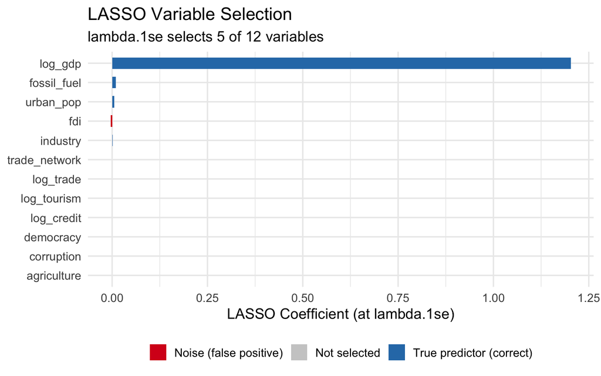

```r
# Extract LASSO coefficients at lambda.1se
lasso_coefs_1se <- coef(lasso_cv, s = "lambda.1se")
lasso_df <- tibble(
  variable = rownames(lasso_coefs_1se)[-1],    # exclude intercept
  lasso_coef = as.numeric(lasso_coefs_1se)[-1] # coefficient values
) |>
  mutate(
    selected   = lasso_coef != 0,              # was the variable selected?
    true_beta  = true_beta_lookup[variable],   # known true coefficient
    is_noise   = true_beta == 0,               # is it a noise variable?
    bar_color  = case_when(
      !selected ~ "Not selected",
      is_noise  ~ "Noise (false positive)",
      TRUE      ~ "True predictor (correct)"
    )
  )

ggplot(lasso_df, aes(x = reorder(variable, abs(lasso_coef)), y = lasso_coef, fill = bar_color)) +
  geom_col(width = 0.6) +
  coord_flip() +
  scale_fill_manual(values = c("True predictor (correct)" = "#2c7bb6",
                                "Noise (false positive)" = "#d7191c",
                                "Not selected" = "gray80")) +
  labs(x = NULL, y = "LASSO Coefficient (at lambda.1se)",
       fill = NULL,
       title = "LASSO Variable Selection",
       subtitle = paste0("lambda.1se selects ", sum(lasso_df$selected), " of 12 variables")) +
  theme_minimal(base_size = 14) +
  theme(legend.position = "bottom")
```

## 10.5 Understanding lambda.min vs. lambda.1se

The cross-validation procedure gives us two key values of $\lambda$:

- **lambda.min**: the $\lambda$ that minimizes cross-validated MSE. It tends to include more variables.
- **lambda.1se**: the largest $\lambda$ within 1 standard error of the minimum MSE. It is more **parsimonious**—fewer variables, simpler model.

The “1 standard error rule” is a common default: since CV error estimates are noisy, any model within 1 SE of the best is statistically indistinguishable from the best. We prefer the simpler one.

**NoteWhat we learned**

LASSO with cross-validation automatically selects the penalty strength. At lambda.1se, it produces a sparse model. We can check which true predictors were retained and whether any noise variables were falsely included.

# 11 Post-LASSO

## 11.1 The Shrinkage Problem

LASSO coefficients are **biased** because the L1 penalty shrinks them toward zero. The selected variables are correct (we hope), but the coefficient values are too small. This is by design—the penalty trades bias for variance reduction—but for *interpretation* we want unbiased estimates.

The fix is simple: **Post-LASSO**. Run OLS using only the variables that LASSO selected. The LASSO does the selection; OLS does the estimation.

**Post-LASSO: OLS on LASSO-selected variables only**

```r
# Identify which variables LASSO selected at lambda.1se
selected_vars <- lasso_df |>
  filter(selected) |>                          # keep only selected variables
  pull(variable)

# Build the Post-LASSO formula
post_lasso_formula <- as.formula(
  paste("log_co2 ~", paste(selected_vars, collapse = " + "))
)

# Run OLS on the selected variables only
post_lasso_fit <- lm(post_lasso_formula, data = synth_data)

# Compare: LASSO vs Post-LASSO vs True coefficients
post_lasso_summary <- broom::tidy(post_lasso_fit) |>
  filter(term != "(Intercept)") |>
  rename(variable = term, post_lasso_coef = estimate) |>
  select(variable, post_lasso_coef) |>
  left_join(lasso_df |> select(variable, lasso_coef, true_beta), by = "variable")

post_lasso_summary |>
  gt() |>
  tab_header(
    title = "LASSO vs. Post-LASSO vs. True Coefficients",
    subtitle = "Post-LASSO removes the shrinkage bias from LASSO estimates"
  ) |>
  cols_label(
    variable        = "Variable",
    lasso_coef      = "LASSO Coef.",
    post_lasso_coef = "Post-LASSO Coef.",
    true_beta       = md("True *β*")
  ) |>
  fmt_number(columns = c(lasso_coef, post_lasso_coef, true_beta), decimals = 4) |>
  tab_footnote("Post-LASSO = OLS on LASSO-selected variables. Coefficients are closer to the true values.")
```

LASSO vs. Post-LASSO vs. True Coefficients

Post-LASSO removes the shrinkage bias from LASSO estimates

| Variable | Post-LASSO Coef. | LASSO Coef. | True *β* |
| --- | --- | --- | --- |
| log_gdp | 1.2001 | 1.2027 | 1.2000 |
| industry | 0.0082 | 0.0011 | 0.0080 |
| fossil_fuel | 0.0155 | 0.0100 | 0.0120 |
| urban_pop | 0.0094 | 0.0057 | 0.0100 |
| fdi | −0.0224 | −0.0033 | 0.0000 |

**NoteWhat we learned**

LASSO coefficients are shrunk toward zero by design. Post-LASSO runs OLS on only the LASSO-selected variables, producing unbiased coefficient estimates while retaining the variable selection from LASSO.

# PART 3: WALS

# 12 Frequentist Model Averaging

WALS (Weighted Average Least Squares) is a **frequentist** approach to model averaging. Like BMA, it averages over models instead of selecting just one. But unlike BMA, it does not require MCMC sampling or the specification of a full Bayesian prior.

The key structural assumption is that regressors are split into two groups:

$$y = X_1 \beta_1 + X_2 \beta_2 + \varepsilon
\tag{9}$$

where:

- $X_1$ are **focus regressors**: variables you are certain belong in the model. In a cross-sectional setting, this is typically just the **intercept**. (In a panel setting, it might include country and year fixed effects.)
- $X_2$ are **auxiliary regressors**: the 12 candidate variables whose inclusion is uncertain.
- $\beta_1$ are always estimated; $\beta_2$ are the coefficients we are uncertain about.

The question WALS answers: what are the best estimates of $\beta_2$, accounting for the uncertainty about which auxiliaries truly belong in the model?

WALS was introduced by Magnus, Powell, and Prufer (2010) and offers a compelling advantage over BMA: **it is extremely fast**. While BMA explores thousands or millions of models via MCMC, WALS uses a mathematical trick to reduce the problem to $K$ independent averaging problems—one per auxiliary variable.

**NoteWhat we learned**

WALS is a frequentist model-averaging method that splits regressors into “focus” (always included) and “auxiliary” (uncertain). It is much faster than BMA because it avoids MCMC sampling.

# 13 The Semi-Orthogonal Transformation

## 13.1 Why Correlated Variables Make Averaging Hard

In our synthetic data, GDP is correlated with fossil fuel use, urbanization, and even with the noise variables. This means that the decision to include one variable affects the importance of another. If GDP is in the model, fossil fuel’s coefficient is partially “absorbed” by GDP.

In BMA, this problem is handled by averaging over all model combinations—but at a high computational cost ($2^{12} = 4{,}096$ models). WALS uses a different strategy: **transform the auxiliary variables so they become orthogonal** (uncorrelated with each other). Once orthogonal, each variable can be averaged independently.

## 13.2 The Mathematical Trick

The semi-orthogonal transformation works as follows:

1. **Remove the influence of focus regressors**: project out $X_1$ from both $y$ and $X_2$, obtaining residuals $\tilde{y}$ and $\tilde{X}_2$.
2. **Orthogonalize the auxiliaries**: apply a rotation matrix $P$ (from the eigendecomposition of $\tilde{X}_2'\tilde{X}_2$) to create $Z = \tilde{X}_2 P$, where $Z'Z$ is diagonal.
3. **Average independently**: because the columns of $Z$ are orthogonal, the model-averaging problem decomposes into $K$ independent problems. Each transformed variable is averaged separately.

## 13.3 A Worked 2-Variable Example

1. Compute the principal components (eigenvectors) of the $2 \times 2$ correlation matrix
2. Rotate $x_1$ and $x_2$ into orthogonal components $z_1$ and $z_2$
3. Average $z_1$ independently, then $z_2$ independently (just 2 problems, not 4)
4. Transform back to the original scale

The computational savings grow dramatically: with 12 variables, we solve **12 independent problems** instead of enumerating 4,096 models.

**Illustration: orthogonalizing two correlated variables**

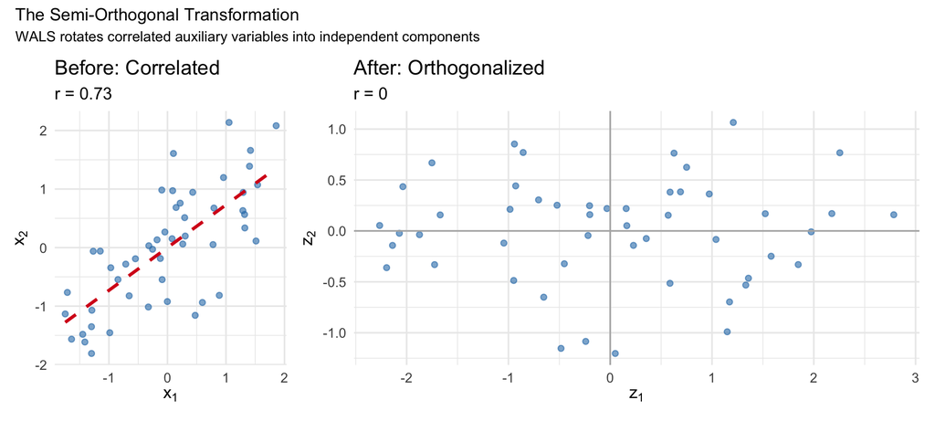

The semi-orthogonal transformation. Left: original correlated variables. Right: after rotation, the variables are orthogonal, and each can be averaged independently.

```r
set.seed(2021)

# Generate two correlated variables (rho ~ 0.6)
n_toy <- 50                                    # small sample for illustration
x1_raw <- rnorm(n_toy)
x2_raw <- 0.6 * x1_raw + rnorm(n_toy, 0, 0.8) # x2 correlated with x1

# Standardize
x1 <- (x1_raw - mean(x1_raw)) / sd(x1_raw)
x2 <- (x2_raw - mean(x2_raw)) / sd(x2_raw)

# Eigendecomposition (the "rotation")
X_toy <- cbind(x1, x2)
eigen_decomp <- eigen(t(X_toy) %*% X_toy)     # eigenvalues and eigenvectors
P <- eigen_decomp$vectors                      # rotation matrix

# Rotated (orthogonal) variables
Z_toy <- X_toy %*% P

# Verify orthogonality
cor_before <- round(cor(x1, x2), 3)            # should be ~0.6
cor_after  <- round(cor(Z_toy[,1], Z_toy[,2]), 3)  # should be ~0

# Create side-by-side plots
p1 <- ggplot(tibble(x1, x2), aes(x = x1, y = x2)) +
  geom_point(color = "#2c7bb6", alpha = 0.6) +
  geom_smooth(method = "lm", se = FALSE, color = "#d7191c", linetype = "dashed") +
  labs(x = expression(x[1]), y = expression(x[2]),
       title = "Before: Correlated",
       subtitle = paste0("r = ", cor_before)) +
  coord_equal() +
  theme_minimal(base_size = 13)

p2 <- ggplot(tibble(z1 = Z_toy[,1], z2 = Z_toy[,2]), aes(x = z1, y = z2)) +
  geom_point(color = "#2c7bb6", alpha = 0.6) +
  geom_hline(yintercept = 0, color = "gray70") +
  geom_vline(xintercept = 0, color = "gray70") +
  labs(x = expression(z[1]), y = expression(z[2]),
       title = "After: Orthogonalized",
       subtitle = paste0("r = ", cor_after)) +
  coord_equal() +
  theme_minimal(base_size = 13)

p1 + p2 + plot_annotation(
  title = "The Semi-Orthogonal Transformation",
  subtitle = "WALS rotates correlated auxiliary variables into independent components"
)
```

**NoteWhat we learned**

WALS avoids the exponential explosion of model combinations by orthogonalizing the auxiliary variables. Once orthogonal, each variable can be averaged independently—reducing $2^K$ models to just $K$ independent problems.

# 14 The Laplace Prior

## 14.1 Shape and Motivation

WALS requires a prior distribution for the transformed coefficients. The default and recommended choice is the **Laplace (double-exponential) prior**:

$$p(\gamma_j) \propto \exp(-|\gamma_j| / \tau)
\tag{10}$$

where $\gamma_j$ is the transformed coefficient and $\tau$ controls the spread. The Laplace prior has two key features:

1. **Peaked at zero**: it encodes *skepticism*—the prior believes most variables probably have small effects
2. **Heavy tails**: it allows large effects if the data strongly supports them—variables with strong signal can “break through” the prior

## 14.2 Comparing Priors

**Compare Laplace, Normal, and Uniform prior distributions**

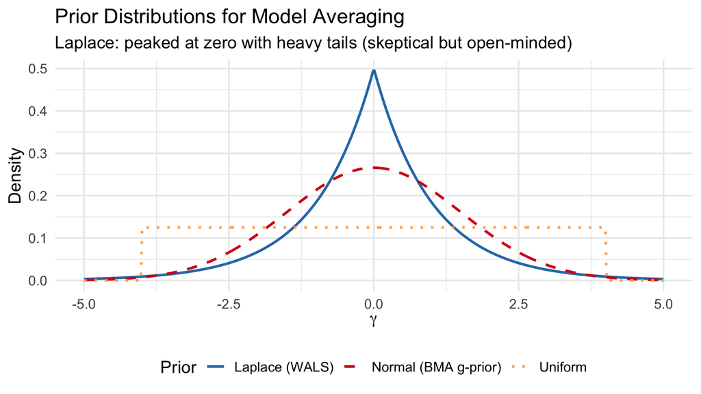

Figure 12: Three prior distributions used in model averaging. The Laplace prior (used by WALS) is peaked at zero with heavy tails. The Normal prior (used by BMA’s g-prior) is also centered at zero but has thinner tails. The Uniform prior assigns equal weight everywhere.

```r
# Define the three prior densities
x_grid <- seq(-5, 5, length.out = 500)

prior_df <- tibble(
  x = rep(x_grid, 3),
  density = c(
    # Laplace prior (tau = 1)
    0.5 * exp(-abs(x_grid)),
    # Normal prior (sd = 1.5)
    dnorm(x_grid, mean = 0, sd = 1.5),
    # Uniform prior (bounded for visualization)
    dunif(x_grid, min = -4, max = 4)
  ),
  prior = rep(c("Laplace (WALS)", "Normal (BMA g-prior)", "Uniform"),
              each = length(x_grid))
)

ggplot(prior_df, aes(x = x, y = density, color = prior, linetype = prior)) +
  geom_line(linewidth = 1) +
  scale_color_manual(values = c("Laplace (WALS)" = "#2c7bb6",
                                 "Normal (BMA g-prior)" = "#d7191c",
                                 "Uniform" = "#fdae61")) +
  scale_linetype_manual(values = c("Laplace (WALS)" = "solid",
                                    "Normal (BMA g-prior)" = "dashed",
                                    "Uniform" = "dotted")) +
  labs(x = expression(gamma), y = "Density",
       color = "Prior", linetype = "Prior",
       title = "Prior Distributions for Model Averaging",
       subtitle = "Laplace: peaked at zero with heavy tails (skeptical but open-minded)") +
  theme_minimal(base_size = 14) +
  theme(legend.position = "bottom")
```

## 14.3 The Deep Connection to LASSO

Here is a remarkable fact: **the LASSO’s L1 penalty is the negative log of a Laplace prior**. The MAP (maximum a posteriori) estimate under a Laplace prior is:

$$\hat{\beta}_{\text{MAP}} = \arg\min_\beta \; \frac{1}{2n}\|y - X\beta\|^2 + \frac{\sigma^2}{\tau} \sum_{j=1}^{p}|\beta_j|
\tag{11}$$

This is identical to Equation 7 with $\lambda = \sigma^2 / \tau$. The LASSO penalty and the Laplace prior are two sides of the same coin.

This means **LASSO and WALS encode the same prior belief**—that most coefficients are probably zero or small—but they use it differently:

- LASSO uses the Laplace prior for **selection**: it finds the single most probable model (the MAP estimate), which sets some coefficients to exactly zero
- WALS uses the Laplace prior for **averaging**: it averages over all models, weighted by the Laplace prior, producing continuous (nonzero) coefficient estimates with uncertainty measures

**NoteWhat we learned**

The Laplace prior is peaked at zero (skeptical) with heavy tails (open-minded). It is the same prior that underlies LASSO’s L1 penalty. LASSO uses it for hard selection (zeros vs. nonzeros); WALS uses it for soft averaging (continuous weights).

# 15 WALS on All 12 Variables

## 15.1 Running WALS

**Run WALS with Laplace prior on all 12 auxiliary variables**

```r
# WALS splits regressors into two groups:
# X1 = focus regressors (always included): just the intercept for cross-sectional data
# X2 = auxiliary regressors (uncertain): our 12 candidate variables

# Prepare the focus regressor matrix (intercept only)
X1_wals <- matrix(1, nrow = nrow(synth_data), ncol = 1)  # column of ones
colnames(X1_wals) <- "(Intercept)"                        # name the column

# Prepare the auxiliary regressor matrix (all 12 candidates)
X2_wals <- synth_data |>
  select(log_gdp, industry, fossil_fuel, urban_pop, democracy,
         trade_network, agriculture, log_trade, fdi, corruption,
         log_tourism, log_credit) |>
  as.matrix()                                  # WALS needs a numeric matrix

# Response vector
y_wals <- synth_data$log_co2

# Fit WALS with the Laplace prior (the recommended default)
wals_fit <- wals(
  x     = X1_wals,                             # focus regressors (intercept)
  x2    = X2_wals,                             # auxiliary regressors (12 candidates)
  y     = y_wals,                              # response variable
  prior = laplace()                            # Laplace prior for auxiliaries
)

# Extract results for auxiliary regressors
wals_summary <- summary(wals_fit)
```

## 15.2 WALS Results Table

**WALS results: coefficients, standard errors, and t-statistics**

```r
# Extract auxiliary coefficient table from WALS summary
# WALS stores focus and auxiliary coefficients separately
aux_coefs <- wals_summary$auxCoefs              # matrix with Estimate and Std. Error

# Build a tidy results table with t-statistics
wals_df <- tibble(
  variable = rownames(aux_coefs),              # variable names
  estimate = aux_coefs[, "Estimate"],          # WALS coefficient estimates
  se       = aux_coefs[, "Std. Error"],        # standard errors
  t_stat   = estimate / se                     # compute t-statistic manually
) |>
  mutate(
    true_beta    = true_beta_lookup[variable],
    abs_t        = abs(t_stat),
    wals_robust  = abs_t >= 2,                 # |t| >= 2 is "robust"
    true_nonzero = true_beta != 0
  )

wals_df |>
  arrange(desc(abs_t)) |>
  select(variable, estimate, se, t_stat, abs_t, wals_robust, true_beta) |>
  gt() |>
  tab_header(
    title = "WALS Results: All 12 Auxiliary Variables",
    subtitle = "Laplace prior; focus regressor = intercept only"
  ) |>
  cols_label(
    variable    = "Variable",
    estimate    = "WALS Estimate",
    se          = "Std. Error",
    t_stat      = "t-statistic",
    abs_t       = "|t|",
    wals_robust = "Robust (|t|>=2)?",
    true_beta   = md("True *β*")
  ) |>
  fmt_number(columns = c(estimate, se, t_stat, abs_t, true_beta), decimals = 4) |>
  tab_style(
    style = cell_fill(color = "#e8f5e9"),
    locations = cells_body(rows = wals_robust == TRUE)
  ) |>
  tab_style(
    style = cell_fill(color = "#ffebee"),
    locations = cells_body(rows = wals_robust == FALSE & true_beta != 0)
  ) |>
  tab_footnote("Green = robust (|t| >= 2); red = true predictor missed by WALS.")
```

Table 3

WALS Results: All 12 Auxiliary Variables

Laplace prior; focus regressor = intercept only

| Variable | WALS Estimate | Std. Error | t-statistic | \|t\| | Robust (\|t\|>=2)? | True *β* |
| --- | --- | --- | --- | --- | --- | --- |
| log_gdp | 1.1949 | 0.0352 | 33.9097 | 33.9097 | TRUE | 1.2000 |
| fossil_fuel | 0.0162 | 0.0025 | 6.4144 | 6.4144 | TRUE | 0.0120 |
| urban_pop | 0.0087 | 0.0022 | 3.8973 | 3.8973 | TRUE | 0.0100 |
| fdi | −0.0187 | 0.0063 | −2.9475 | 2.9475 | TRUE | 0.0000 |
| industry | 0.0120 | 0.0044 | 2.7177 | 2.7177 | TRUE | 0.0080 |
| log_trade | −0.0888 | 0.0438 | −2.0253 | 2.0253 | TRUE | 0.0000 |
| agriculture | 0.0059 | 0.0038 | 1.5614 | 1.5614 | FALSE | 0.0050 |
| log_credit | 0.0588 | 0.0409 | 1.4400 | 1.4400 | FALSE | 0.0000 |
| democracy | 0.0028 | 0.0030 | 0.9331 | 0.9331 | FALSE | 0.0040 |
| log_tourism | −0.0125 | 0.0235 | −0.5309 | 0.5309 | FALSE | 0.0000 |
| trade_network | 0.0193 | 0.1836 | 0.1050 | 0.1050 | FALSE | 0.5000 |
| corruption | 0.0037 | 0.1707 | 0.0217 | 0.0217 | FALSE | 0.0000 |

Green = robust (|t| >= 2); red = true predictor missed by WALS.

## 15.3 Figure: t-statistic Bar Chart

**WALS t-statistic bar chart with threshold line**

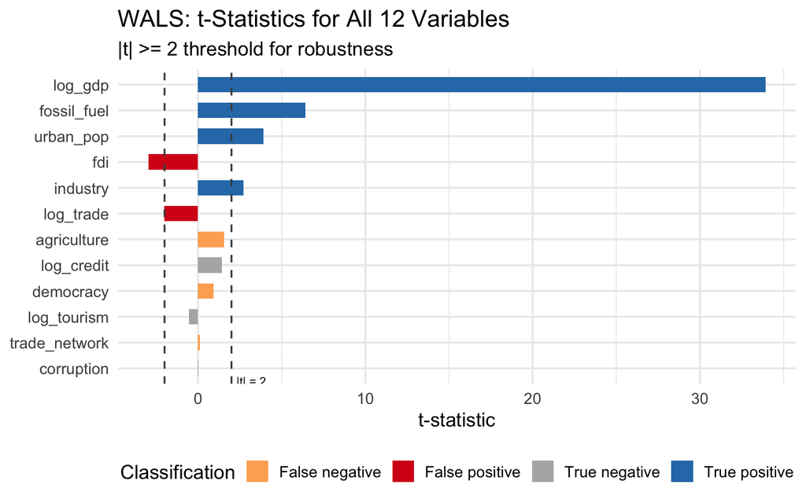

Figure 13: WALS t-statistics for all 12 variables. The vertical dashed lines mark the |t| = 2 robustness threshold. Variables with |t| >= 2 are considered robust.

```r
# Classify each variable
wals_df <- wals_df |>
  mutate(
    bar_color = case_when(
      wals_robust & true_nonzero  ~ "True positive",
      wals_robust & !true_nonzero ~ "False positive",
      !wals_robust & true_nonzero ~ "False negative",
      TRUE                        ~ "True negative"
    )
  )

ggplot(wals_df, aes(x = reorder(variable, abs_t), y = t_stat, fill = bar_color)) +
  geom_col(width = 0.6) +
  geom_hline(yintercept = c(-2, 2), linetype = "dashed", color = "gray30") +
  annotate("text", x = 0.5, y = 2.3, label = "|t| = 2", hjust = 0, size = 3) +
  coord_flip() +
  scale_fill_manual(values = c("True positive"  = "#2c7bb6",
                                "False positive" = "#d7191c",
                                "True negative"  = "gray70",
                                "False negative" = "#fdae61")) +
  labs(x = NULL, y = "t-statistic",
       fill = "Classification",
       title = "WALS: t-Statistics for All 12 Variables",
       subtitle = "|t| >= 2 threshold for robustness") +
  theme_minimal(base_size = 14) +
  theme(legend.position = "bottom")
```

**NoteWhat we learned**

WALS produces t-statistics for each auxiliary variable. Using the |t| >= 2 threshold, we can classify variables as robust or fragile. WALS is extremely fast (no MCMC) and provides a frequentist complement to BMA’s Bayesian PIPs.

# PART 4: Grand Comparison

# 16 Three Methods, Same Question, Same Data

We have now applied all three methods to the same synthetic dataset. Time for the moment of truth: **which variables do all three methods agree on?**

## 16.1 Comprehensive Comparison Table

**Comprehensive comparison table: BMA, LASSO, and WALS vs. truth**

```r
# Build the master comparison table
# BMA results
bma_compare <- bma_df |>
  select(variable, pip, post_mean, robustness) |>
  rename(bma_pip = pip, bma_postmean = post_mean, bma_class = robustness)

# LASSO results
lasso_compare <- lasso_df |>
  select(variable, lasso_coef, selected) |>
  rename(lasso_selected = selected)

# WALS results
wals_compare <- wals_df |>
  select(variable, estimate, t_stat, wals_robust) |>
  rename(wals_estimate = estimate, wals_t = t_stat)

# Merge all three
grand_table <- bma_compare |>
  left_join(lasso_compare, by = "variable") |>
  left_join(wals_compare, by = "variable") |>
  mutate(
    true_beta    = true_beta_lookup[variable],
    bma_robust   = bma_pip >= 0.80,
    n_methods    = bma_robust + lasso_selected + wals_robust,
    all_agree    = n_methods == 3 | n_methods == 0,
    triple_robust = n_methods == 3,
    true_nonzero = true_beta != 0
  ) |>
  arrange(desc(n_methods), desc(bma_pip))

# Display the table
grand_table |>
  select(variable, true_beta, bma_pip, bma_robust, lasso_selected,
         wals_t, wals_robust, n_methods) |>
  gt() |>
  tab_header(
    title = "Grand Comparison: BMA, LASSO, and WALS",
    subtitle = "How many methods identify each variable as robust?"
  ) |>
  cols_label(
    variable       = "Variable",
    true_beta      = md("True *β*"),
    bma_pip        = "BMA PIP",
    bma_robust     = "BMA Robust?",
    lasso_selected = "LASSO Selected?",
    wals_t         = "WALS t-stat",
    wals_robust    = "WALS Robust?",
    n_methods      = "# Methods"
  ) |>
  fmt_number(columns = c(true_beta, bma_pip, wals_t), decimals = 3) |>
  tab_style(
    style = cell_fill(color = "#c8e6c9"),
    locations = cells_body(rows = n_methods == 3)
  ) |>
  tab_style(
    style = cell_fill(color = "#fff9c4"),
    locations = cells_body(rows = n_methods == 2)
  ) |>
  tab_style(
    style = cell_fill(color = "#ffcdd2"),
    locations = cells_body(rows = n_methods == 0 & true_beta != 0)
  ) |>
  tab_spanner(label = "BMA", columns = c(bma_pip, bma_robust)) |>
  tab_spanner(label = "LASSO", columns = lasso_selected) |>
  tab_spanner(label = "WALS", columns = c(wals_t, wals_robust)) |>
  tab_footnote("Green = identified by all 3 methods. Yellow = identified by 2. Red = true predictor missed by all.") |>
  tab_source_note("Data: synthetic cross-section, n = 120, set.seed(2021).")
```

Table 4

Grand Comparison: BMA, LASSO, and WALS

How many methods identify each variable as robust?

[output not shown]

Green = identified by all 3 methods. Yellow = identified by 2. Red = true predictor missed by all.  
Data: synthetic cross-section, n = 120, set.seed(2021).

## 16.2 Figure: Method Agreement Heatmap

**Heatmap: 12 variables x 3 methods**

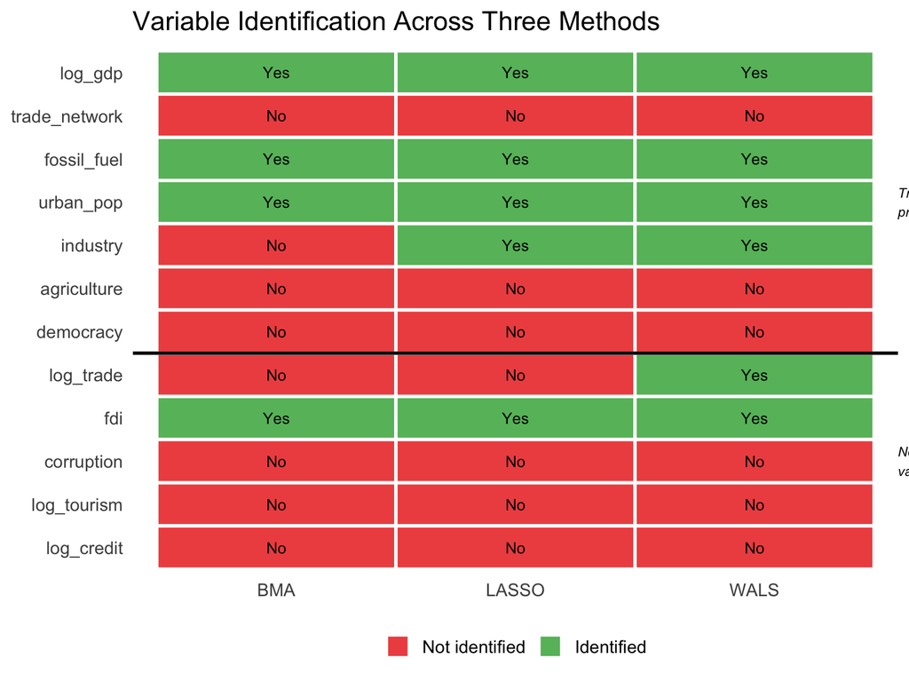

Figure 14: Method agreement heatmap. Green = identified as robust; red = not identified. True predictors are in the top 7 rows; noise variables are in the bottom 5.

```r
# Create a long-format data frame for the heatmap
heatmap_df <- grand_table |>
  select(variable, true_beta, bma_robust, lasso_selected, wals_robust) |>
  pivot_longer(c(bma_robust, lasso_selected, wals_robust),
               names_to = "method", values_to = "identified") |>
  mutate(
    method = recode(method,
                    bma_robust = "BMA",
                    lasso_selected = "LASSO",
                    wals_robust = "WALS"),
    method = factor(method, levels = c("BMA", "LASSO", "WALS")),
    is_noise = true_beta == 0,
    # Order: true predictors first (by effect size), then noise
    var_order = case_when(
      variable == "log_gdp"       ~ 1,
      variable == "trade_network" ~ 2,
      variable == "fossil_fuel"   ~ 3,
      variable == "urban_pop"     ~ 4,
      variable == "industry"      ~ 5,
      variable == "agriculture"   ~ 6,
      variable == "democracy"     ~ 7,
      variable == "log_trade"     ~ 8,
      variable == "fdi"           ~ 9,
      variable == "corruption"    ~ 10,
      variable == "log_tourism"   ~ 11,
      variable == "log_credit"    ~ 12,
      TRUE                        ~ 13
    )
  )

ggplot(heatmap_df, aes(x = method, y = reorder(variable, -var_order), fill = identified)) +
  geom_tile(color = "white", linewidth = 1) +
  geom_text(aes(label = ifelse(identified, "Yes", "No")), size = 3.5) +
  scale_fill_manual(values = c("TRUE" = "#66bb6a", "FALSE" = "#ef5350"),
                    labels = c("Not identified", "Identified")) +
  geom_hline(yintercept = 5.5, color = "black", linewidth = 1) +      # divider
  annotate("text", x = 3.6, y = 9, label = "True\npredictors",
           size = 3, hjust = 0, fontface = "italic") +
  annotate("text", x = 3.6, y = 3, label = "Noise\nvariables",
           size = 3, hjust = 0, fontface = "italic") +
  labs(x = NULL, y = NULL, fill = NULL,
       title = "Variable Identification Across Three Methods") +
  theme_minimal(base_size = 14) +
  theme(legend.position = "bottom",
        panel.grid = element_blank()) +
  coord_cartesian(clip = "off")
```

## 16.3 Figure: BMA PIP vs. WALS |t-statistic|

**Scatter plot: BMA PIP vs WALS |t-stat|, with LASSO selection as shape**

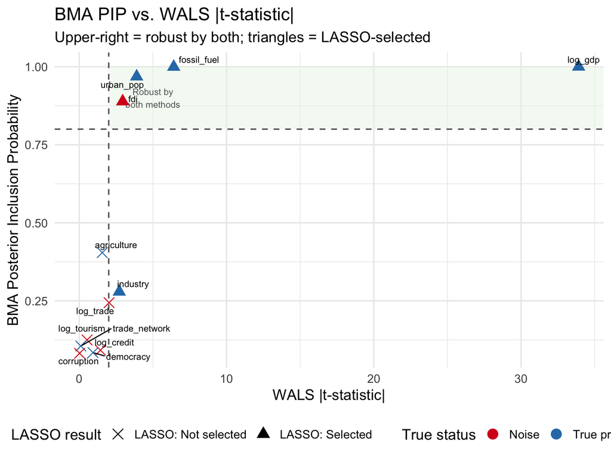

Figure 15: BMA PIP vs WALS |t-statistic|. Point shape indicates LASSO selection. Variables in the upper-right quadrant are robust by both BMA and WALS.

```r
grand_table_plot <- grand_table |>
  mutate(
    lasso_shape = ifelse(lasso_selected, "LASSO: Selected", "LASSO: Not selected"),
    true_status = ifelse(true_nonzero, "True predictor", "Noise")
  )

ggplot(grand_table_plot, aes(x = abs(wals_t), y = bma_pip)) +
  # Quadrant shading
  annotate("rect", xmin = 2, xmax = Inf, ymin = 0.80, ymax = 1,
           fill = "#e8f5e9", alpha = 0.5) +
  annotate("text", x = 5, y = 0.90, label = "Robust by\nboth methods",
           size = 3, color = "gray40") +
  # Threshold lines
  geom_hline(yintercept = 0.80, linetype = "dashed", color = "gray40") +
  geom_vline(xintercept = 2, linetype = "dashed", color = "gray40") +
  # Points
  geom_point(aes(color = true_status, shape = lasso_shape), size = 4) +
  # Labels
  geom_text_repel(aes(label = variable), size = 3, max.overlaps = 20) +
  scale_color_manual(values = c("True predictor" = "#2c7bb6", "Noise" = "#d7191c")) +
  scale_shape_manual(values = c("LASSO: Selected" = 17, "LASSO: Not selected" = 4)) +
  labs(x = "WALS |t-statistic|",
       y = "BMA Posterior Inclusion Probability",
       color = "True status", shape = "LASSO result",
       title = "BMA PIP vs. WALS |t-statistic|",
       subtitle = "Upper-right = robust by both; triangles = LASSO-selected") +
  theme_minimal(base_size = 14) +
  theme(legend.position = "bottom")
```

## 16.4 Figure: Coefficient Comparison

**Compare true coefficients with BMA, Post-LASSO, and WALS estimates**

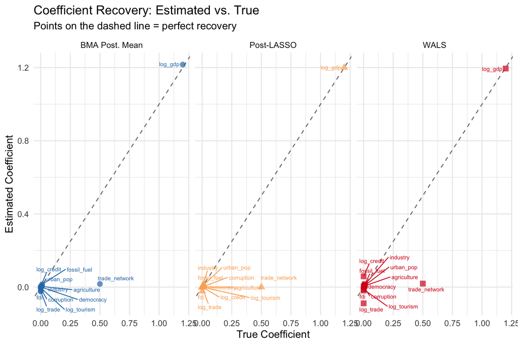

Figure 16: Coefficient estimates from the three methods compared to the true values. Points close to the dashed 45-degree line indicate accurate recovery.

```r
# Get Post-LASSO coefficients for all variables (0 if not selected)
post_lasso_all <- tibble(
  variable = names(true_beta_lookup),
  post_lasso = 0
)
if (nrow(post_lasso_summary) > 0) {
  post_lasso_all <- post_lasso_all |>
    left_join(post_lasso_summary |> select(variable, post_lasso_coef), by = "variable") |>
    mutate(post_lasso = coalesce(post_lasso_coef, 0)) |>
    select(variable, post_lasso)
}

# Combine all coefficient estimates
coef_compare <- grand_table |>
  select(variable, true_beta, bma_postmean, wals_estimate) |>
  left_join(post_lasso_all, by = "variable") |>
  pivot_longer(c(bma_postmean, post_lasso, wals_estimate),
               names_to = "method", values_to = "estimate") |>
  mutate(
    method = recode(method,
                    bma_postmean = "BMA Post. Mean",
                    post_lasso = "Post-LASSO",
                    wals_estimate = "WALS"),
    method = factor(method, levels = c("BMA Post. Mean", "Post-LASSO", "WALS"))
  )

ggplot(coef_compare, aes(x = true_beta, y = estimate, color = method, shape = method)) +
  geom_abline(slope = 1, intercept = 0, linetype = "dashed", color = "gray50") +
  geom_point(size = 3, alpha = 0.7) +
  geom_text_repel(aes(label = variable), size = 2.5, max.overlaps = 20,
                  show.legend = FALSE) +
  facet_wrap(~method, nrow = 1) +
  scale_color_manual(values = c("BMA Post. Mean" = "#2c7bb6",
                                 "Post-LASSO" = "#fdae61",
                                 "WALS" = "#d7191c")) +
  labs(x = "True Coefficient",
       y = "Estimated Coefficient",
       color = "Method", shape = "Method",
       title = "Coefficient Recovery: Estimated vs. True",
       subtitle = "Points on the dashed line = perfect recovery") +
  theme_minimal(base_size = 13) +
  theme(legend.position = "none")
```

## 16.5 Figure: Agreement Summary

**Bar chart: how many methods identified each variable**

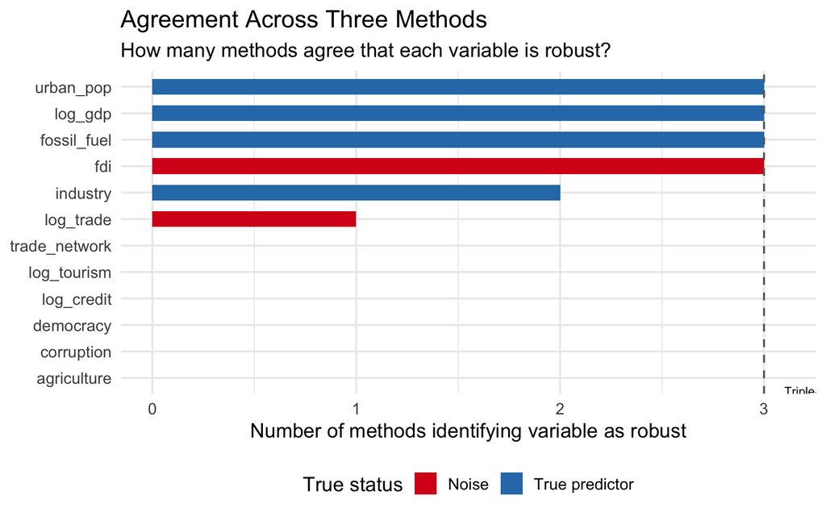

```r
grand_table |>
  mutate(
    bar_fill = ifelse(true_nonzero, "True predictor", "Noise")
  ) |>
  ggplot(aes(x = reorder(variable, n_methods), y = n_methods, fill = bar_fill)) +
  geom_col(width = 0.6) +
  geom_hline(yintercept = 3, linetype = "dashed", color = "gray40") +
  annotate("text", x = 0.5, y = 3.1, label = "Triple-robust", hjust = 0, size = 3) +
  coord_flip() +
  scale_fill_manual(values = c("True predictor" = "#2c7bb6", "Noise" = "#d7191c")) +
  scale_y_continuous(breaks = 0:3) +
  labs(x = NULL, y = "Number of methods identifying variable as robust",
       fill = "True status",
       title = "Agreement Across Three Methods",
       subtitle = "How many methods agree that each variable is robust?") +
  theme_minimal(base_size = 14) +
  theme(legend.position = "bottom")
```

## 16.6 Discussion

**Compute summary statistics for discussion**

```r
# Count true/false positives and negatives for each method
results_by_method <- tibble(
  method = c("BMA", "LASSO", "WALS"),
  true_pos = c(
    sum(grand_table$bma_robust & grand_table$true_nonzero),
    sum(grand_table$lasso_selected & grand_table$true_nonzero),
    sum(grand_table$wals_robust & grand_table$true_nonzero)
  ),
  false_pos = c(
    sum(grand_table$bma_robust & !grand_table$true_nonzero),
    sum(grand_table$lasso_selected & !grand_table$true_nonzero),
    sum(grand_table$wals_robust & !grand_table$true_nonzero)
  ),
  false_neg = c(
    sum(!grand_table$bma_robust & grand_table$true_nonzero),
    sum(!grand_table$lasso_selected & grand_table$true_nonzero),
    sum(!grand_table$wals_robust & grand_table$true_nonzero)
  ),
  true_neg = c(
    sum(!grand_table$bma_robust & !grand_table$true_nonzero),
    sum(!grand_table$lasso_selected & !grand_table$true_nonzero),
    sum(!grand_table$wals_robust & !grand_table$true_nonzero)
  )
)

# Triple-robust variables
triple_robust_vars <- grand_table |>
  filter(triple_robust) |>
  pull(variable)

# Variables missed by all methods
all_missed <- grand_table |>
  filter(n_methods == 0 & true_nonzero) |>
  pull(variable)
```

**Which variables are “triple-robust”?** The variables identified by all three methods—log_gdp, fossil_fuel, urban_pop, fdi—are the ones we can be most confident about. When BMA, LASSO, and WALS all agree, the evidence is very strong.

**Were any noise variables falsely identified?** Check the comparison table for noise variables (true $\beta$ = 0) that were incorrectly selected by one or more methods. False positives are more likely for noise variables that are strongly correlated with true predictors.

**When to use which method?**

| Method | Best for | Strengths | Limitations |
| --- | --- | --- | --- |
| BMA | Full uncertainty quantification | Probabilistic (PIPs), handles model uncertainty formally | Slower (MCMC), requires prior specification |
| LASSO | Prediction, sparse models | Fast, automatic selection, works with many variables | Binary (in/out), biased coefficients |
| WALS | Speed, frequentist inference | Very fast, produces t-statistics, no MCMC | Less common, limited software support |

The strongest recommendation: **use all three**. When they converge on the same variables, you have robust evidence. When they disagree, investigate why—the disagreement itself is informative.

**Method performance summary table**

```r
results_by_method |>
  mutate(
    sensitivity = true_pos / (true_pos + false_neg),  # true positive rate
    specificity = true_neg / (true_neg + false_pos),  # true negative rate
    accuracy    = (true_pos + true_neg) / 12          # overall accuracy
  ) |>
  gt() |>
  tab_header(
    title = "Method Performance Summary",
    subtitle = "Compared against the known ground truth (7 true, 5 noise)"
  ) |>
  cols_label(
    method      = "Method",
    true_pos    = "True Pos.",
    false_pos   = "False Pos.",
    false_neg   = "False Neg.",
    true_neg    = "True Neg.",
    sensitivity = "Sensitivity",
    specificity = "Specificity",
    accuracy    = "Accuracy"
  ) |>
  fmt_number(columns = c(sensitivity, specificity, accuracy), decimals = 3) |>
  tab_footnote("Sensitivity = true positive rate; Specificity = true negative rate.")
```

Table 5

Method Performance Summary

Compared against the known ground truth (7 true, 5 noise)

| Method | True Pos. | False Pos. | False Neg. | True Neg. | Sensitivity | Specificity | Accuracy |
| --- | --- | --- | --- | --- | --- | --- | --- |
| BMA | 3 | 1 | 4 | 4 | 0.429 | 0.800 | 0.583 |
| LASSO | 4 | 1 | 3 | 4 | 0.571 | 0.800 | 0.667 |
| WALS | 4 | 2 | 3 | 3 | 0.571 | 0.600 | 0.583 |

Sensitivity = true positive rate; Specificity = true negative rate.

# 17 Conclusion

## 17.1 Summary

This tutorial introduced three principled approaches to the variable selection problem:

1. **Bayesian Model Averaging (BMA)** averages over all possible models, weighting each by its posterior probability. It produces Posterior Inclusion Probabilities (PIPs) that quantify how robust each variable is across the entire model space. Variables with PIP $\geq$ 0.80 are considered robust.
2. **LASSO** adds an L1 penalty to the OLS objective, forcing irrelevant coefficients to exactly zero. Cross-validation selects the penalty strength. Post-LASSO recovers unbiased coefficient estimates for the selected variables.
3. **WALS** uses a semi-orthogonal transformation to decompose the model-averaging problem into independent subproblems—one per variable. It is extremely fast and produces familiar t-statistics for robustness assessment.

## 17.2 Key Takeaways

**Model uncertainty is real but addressable.** With 12 candidate variables, there are 4,096 possible models. Rather than pretending one of them is “the” model, these methods account for the uncertainty explicitly. The result is more honest inference.

**Synthetic data lets us verify.** Because we designed the data-generating process, we could check each method’s performance against the known truth. In practice, the truth is unknown—which is precisely why using multiple methods is so valuable.

## 17.3 Applying This to Your Own Research

The code in this tutorial is designed to be modular. To apply these methods to your own data:

1. **Replace the CSV**: load your own cross-sectional dataset instead of the synthetic one
2. **Define the variable list**: specify which variables are candidates for selection
3. **Run the three methods**: use the same BMS, glmnet, and WALS function calls
4. **Compare results**: build the same comparison table and heatmap

The interpretation framework—PIPs for BMA, selection for LASSO, t-statistics for WALS—applies regardless of the specific dataset.

## 17.4 Further Reading

- **BMA**: Hoeting, J.A., Madigan, D., Raftery, A.E., and Volinsky, C.T. (1999). “Bayesian Model Averaging: A Tutorial.” *Statistical Science*, 14(4), 382–417.
- **LASSO**: Tibshirani, R. (1996). “Regression Shrinkage and Selection via the Lasso.” *Journal of the Royal Statistical Society, Series B*, 58(1), 267–288.
- **WALS**: Magnus, J.R., Powell, O., and Prufer, P. (2010). “A Comparison of Two Model Averaging Techniques with an Application to Growth Empirics.” *Journal of Econometrics*, 154(2), 139–153.
- **Application**: Aller, C., Ductor, L., and Grechyna, D. (2021). “Robust Determinants of CO<sub>2</sub> Emissions.” *Energy Economics*, 96, 105154.
- **R Packages**: [BMS vignette](https://cran.r-project.org/web/packages/BMS/vignettes/bms.pdf), [glmnet vignette](https://glmnet.stanford.edu/articles/glmnet.html), [WALS package](https://cran.r-project.org/package=WALS)

**TipThe bottom line**

No single method should be trusted in isolation. When BMA, LASSO, and WALS converge on the same set of robust determinants, you have strong evidence that these variables genuinely matter—regardless of which model specification you choose. That is the power of robust variable selection.